# R Notebook

```r
rm(list = ls())

# Note the script should be run from the main directory of the repository.

# Checking if we are inside the correct folder, otherwise changing directory to the previous folder
file_exists <- "Session_Info"

if (file.exists(file_exists)) {
  setwd("../")
  if (!file.exists("Code")) {
    print("Please ensure that the script is run from the main repository folder")
  }
} else{
  if (!file.exists("Code")) {
    print("Please ensure that the script is run from the main repository folder")
  }
}

# Functions, general information and packages------------------------------------

if (!require("plyr")) {
  install.packages("plyr")
}
if (!require("ggplot2")) {
  install.packages("ggplot2")
}
if (!require("dplyr")) {
  install.packages("dplyr")
}
if (!require("car")) {
  install.packages("car")
}
if (!require("fitdistrplus")) {
  install.packages("fitdistrplus")
}
if (!require("tidyr")) {
  install.packages("tidyr")
}
if (!require("cxr")) {
  install.packages("cxr")
}
if (!require("MASS")) {
  install.packages("MASS")
}
if (!require("mvtnorm")) {
  install.packages("mvtnorm")
}
if (!require("lme4")) {
  install.packages("lme4")
}
if (!require("lmerTest")) {
  install.packages("lmerTest")
}
if (!require("emmeans")) {
  install.packages("emmeans")
}
if (!require("glmmTMB")) {
  install.packages("glmmTMB")
}
if (!require("DescTools")) {
  install.packages("DescTools")
}
if (!require("performance")) {
  install.packages("performance")
}
if (!require("DHARMa")) {
  install.packages("DHARMa")
}
if (!require("effects")) {
  install.packages("effects")
}
if (!require("marginaleffects")) {
  install.packages("marginaleffects")
}
if (!require("LSAfun")) {
  install.packages("LSAfun")
}
if (!require("arm")) {
  install.packages("arm")
}
if (!require("cowplot")) {
  install.packages("cowplot")
}
if (!require("grid")) {
  install.packages("grid")
}
if (!require("gridExtra")) {
  install.packages("gridExtra")
}

print(getwd())
```

```
## [1] "/Volumes/IF/Desktop/Project_manuscript/Coexistence_cadmium/EcologyLetters/Rev4/Repo_submit"
```

```r
library(plyr)
library(dplyr)
library(ggplot2)
library(car)
library(fitdistrplus)
library(tidyr)
library(cxr)
library(MASS)
library(mvtnorm)
library(lme4)
library(lmerTest)
library(emmeans)
library(glmmTMB)
library(DescTools)
library(performance)
library(DHARMa)
library(effects)
library(marginaleffects)
library(LSAfun)
library(arm)
library(cowplot)
library(grid)
library(gridExtra)

# Creating vectors with regime names to use for plots
regimeTu <- c("Tu \ncontrol", "Tu evolved \n in cadmium")
names(regimeTu) <- c("SR1", "SR2")

regimeTe <- c("Te \n control", "Te evolved \n in cadmium")
names(regimeTe) <- c("SR4", "SR5")
```

# Evaluation

Some pieces of the code take a lot of time to run. We provide the intermediate results to speed up the process. To run the whole code change eval from FALSE to TRUE.

```r
# Evaluation------------------------------------
evaluation <- FALSE
if (!file.exists("./Analyses")) {
  dir.create("./Analyses/")
}
```

# Running cxr

This code takes a bit of time to run. So the intermediate files are provided in the Analyses folder.

To run the code to estimate the parameters with cxr use the scripts Running_cxr_PooledData.R (to obtain the estimates for pooled data) and Running_cxr_Replicates.R (to obtain the estimates for each replicate).

```r
# Running cxr------------------------------------
if (evaluation) {
  print("Running cxr")
  source("./Code/Running_cxr_pooledData.R")
  source("./Code/Running_cxr_Replicates.R")
}

print("Importing parameter estimation")
```

```
## [1] "Importing parameter estimation"
```

# Importing parameter estimates

### Estimated parameters per replicate

```r
# Importing parameter estimates------------------------------------
# Importing the mean parameters
param_all_w0 <- read.csv("./Analyses/cxr_normal_Replicates/parameters_cxr_normal.csv")
# Importing the upper values of the parameters
param_all_w0_upper <- read.csv("./Analyses/cxr_normal_Replicates/parameters_cxr_normal_upper.csv")
# Importing the lower values of the parameters
param_all_w0_lower <- read.csv("./Analyses/cxr_normal_Replicates/parameters_cxr_normal_lower.csv")

# Removing the first column
param_all_w0 <- param_all_w0[, -1]
param_all_w0_upper <- param_all_w0_upper[, -1]
param_all_w0_lower <- param_all_w0_lower[, -1]
```

### Estimated parameters for pooled data

```r
# Importing the mean parameters
param_all_REP <- read.csv("./Analyses/cxr_normal_Pooled/parameters_cxr_normal_Pooled.csv")
# Importing the upper values of the parameters
param_all_REP_upper <- read.csv("./Analyses/cxr_normal_Pooled/parameters_cxr_normal_Pooled_upper.csv")
# Importing the lower values of the parameters
param_all_REP_lower <- read.csv("./Analyses/cxr_normal_Pooled/parameters_cxr_normal_Pooled_lower.csv")

param_all_REP <- param_all_REP[, -1]
param_all_REP_upper <- param_all_REP_upper[, -1]
param_all_REP_lower <- param_all_REP_lower[, -1]

print("Statistical tests")
```

```
## [1] "Statistical tests"
```

# Testing differences in estimated parameters

First thing is to test the distribution of each trait

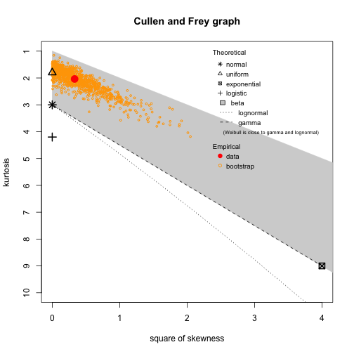

```
## summary statistics
## ------
## min:  1.104136   max:  3.993646
## median:  1.92974
## mean:  2.146675
## estimated sd:  0.9475624
## estimated skewness:  0.5756848
## estimated kurtosis:  2.0368
```

```r
# Statistical analyses------------------------------------
#Using descdist to check potential distributions to test in the model

descdist(param_all_w0$Tu_lambda, discrete = FALSE, boot = 1000)
```

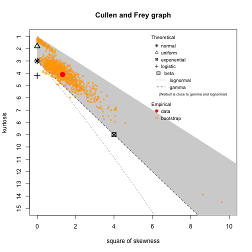

```
## summary statistics
## ------
## min:  1.319446   max:  13.91509
## median:  3.540014
## mean:  4.886738
## estimated sd:  3.286221
## estimated skewness:  1.150387
## estimated kurtosis:  4.102553
```

```r
descdist(param_all_w0$Te_lambda, discrete = FALSE, boot = 1000)
```

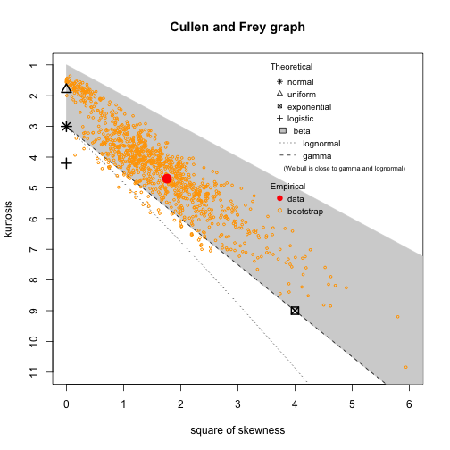

```
## summary statistics
## ------
## min:  0.001037317   max:  0.1146114
## median:  0.01888996
## mean:  0.03021962
## estimated sd:  0.02973419
## estimated skewness:  1.32684
## estimated kurtosis:  4.700326
```

```r
descdist(param_all_w0$Tu_intra, discrete = FALSE, boot = 1000)
```

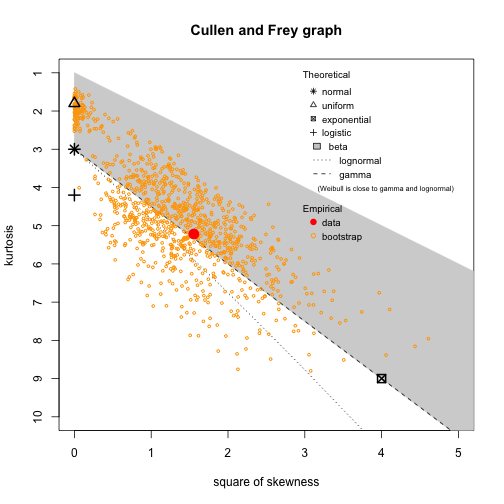

```
## summary statistics
## ------
## min:  -0.09612455   max:  0.1239484
## median:  0.05007978
## mean:  0.05461892
## estimated sd:  0.05186204
## estimated skewness:  -1.247064
## estimated kurtosis:  5.217773
```

```r
descdist(param_all_w0$Te_intra, discrete = FALSE, boot = 1000)
```

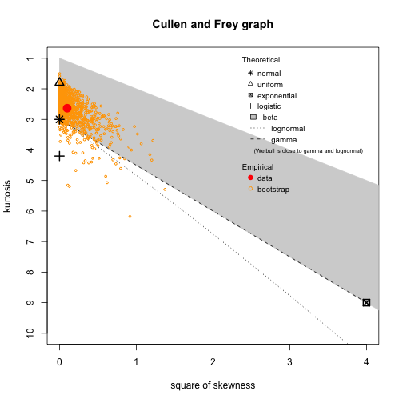

```
## summary statistics
## ------
## min:  -0.02855471   max:  0.1111972
## median:  0.03232658
## mean:  0.03413141
## estimated sd:  0.03543709
## estimated skewness:  0.3150392
## estimated kurtosis:  2.63444
```

```r
descdist(param_all_w0$Tu_inter, discrete = FALSE, boot = 1000)
```

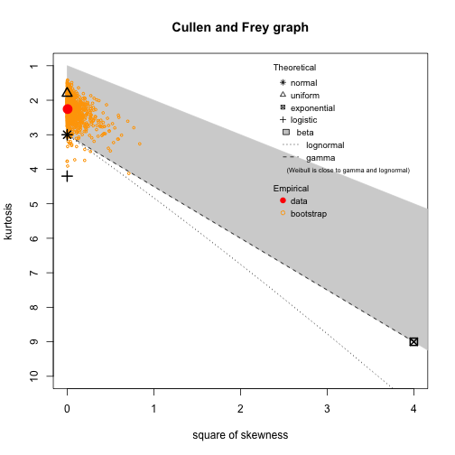

```
## summary statistics
## ------
## min:  -0.04506072   max:  0.2044646
## median:  0.07134627
## mean:  0.07451135
## estimated sd:  0.06208902
## estimated skewness:  0.07218541
## estimated kurtosis:  2.255766
```

```r
descdist(param_all_w0$Te_inter, discrete = FALSE, boot = 1000)
```

This next section corresponds to a series of statistical tests to evaluate changes in growth rate, intraspecific competition and interspecific competition. For each trait we perform a test for Tu and Te species. In the end of each section we provide a summary of the results. These results are cited directly in text or in supplementary tables.

```r
## Does cadmium change parameters? (no evolution)
```

```r
### Growth rate-------
#### Tu-------
##
# Testing the effect of cadmium on growth rate using different distributions
gr_tu_cd_1 <- glmmTMB(Tu_lambda ~ Environment,
                      data = subset(param_all_w0, Tu_Regime == "SR1" &
                                      Te_Regime == "SR4"))
gr_tu_cd_2 <- glmmTMB(
  Tu_lambda ~ Environment,
  data = subset(param_all_w0, Tu_Regime == "SR1" &
                  Te_Regime == "SR4"),
  family = Gamma(link = "log")
)
gr_tu_cd_3 <- glmmTMB(
  Tu_lambda ~ Environment,
  data = subset(param_all_w0, Tu_Regime == "SR1" &
                  Te_Regime == "SR4"),
  family = gaussian(link = "log")
)

AIC(gr_tu_cd_1, gr_tu_cd_2, gr_tu_cd_3)
```

```
##            df      AIC
## gr_tu_cd_1  3 15.60521
## gr_tu_cd_2  3  7.59340
## gr_tu_cd_3  3 15.60521
```

```r
# best model gr_tu_cd_2

summary(gr_tu_cd_2)
```

```
##  Family: Gamma  ( log )
## Formula:
## Tu_lambda ~ Environment
## Data:
## subset(param_all_w0, Tu_Regime == "SR1" & Te_Regime == "SR4")
##
##       AIC       BIC    logLik
##       7.6       8.5      -0.8
## -2*log(L)  df.resid
##       1.6         7
##
##
## Dispersion estimate for Gamma family (sigma^2): 0.0183
##
## Conditional model:
##              Estimate Std. Error
## (Intercept)   0.20483    0.06051
## EnvironmentN  0.92454    0.08557
##              z value Pr(>|z|)
## (Intercept)    3.385 0.000712 ***
## EnvironmentN  10.804  < 2e-16 ***
## ---
## Signif. codes:
##   0 '***' 0.001 '**' 0.01 '*'
##   0.05 '.' 0.1 ' ' 1
```

```
##
##  DHARMa: qgam was unable to calculate quantile regression for quantile 0.25. Possibly to few (unique) data points / predictions. The quantile will be ommited in plots and significance calculations.
```

```
##
##  DHARMa: qgam was unable to calculate quantile regression for quantile 0.5. Possibly to few (unique) data points / predictions. The quantile will be ommited in plots and significance calculations.
```

```
##
##  DHARMa: qgam was unable to calculate quantile regression for quantile 0.75. Possibly to few (unique) data points / predictions. The quantile will be ommited in plots and significance calculations.
```

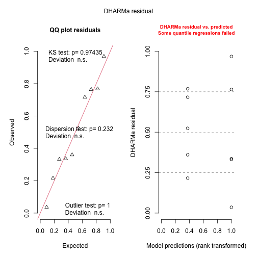

```r
# Testing residual of the best model
simulationOutput <- simulateResiduals(fittedModel = gr_tu_cd_2, plot = F)
plot(simulationOutput)
```

```r
#No problems
```

Cadmium significantly decreases growth rate for Tu.

```r
#### Te----------
```

```r
# Testing the effect of cadmium on growth rate using different distributions
gr_te_cd_1 <- glmmTMB(Te_lambda ~ Environment,
                      data = subset(param_all_w0, Tu_Regime == "SR1" &
                                      Te_Regime == "SR4"))
gr_te_cd_2 <- glmmTMB(
  Te_lambda ~ Environment,
  data = subset(param_all_w0, Tu_Regime == "SR1" &
                  Te_Regime == "SR4"),
  family = Gamma(link = "log")
)
gr_te_cd_3 <- glmmTMB(
  Te_lambda ~ Environment,
  data = subset(param_all_w0, Tu_Regime == "SR1" &
                  Te_Regime == "SR4"),
  family = gaussian(link = "log")
)

AIC(gr_te_cd_1, gr_te_cd_2, gr_te_cd_3)
```

```
##            df      AIC
## gr_te_cd_1  3 52.08537
## gr_te_cd_2  3 38.37946
## gr_te_cd_3  3 52.08537
```

```r
#Best model is gr_te_cd_2

summary(gr_te_cd_2)
```

```
##  Family: Gamma  ( log )
## Formula:
## Te_lambda ~ Environment
## Data:
## subset(param_all_w0, Tu_Regime == "SR1" & Te_Regime == "SR4")
##
##       AIC       BIC    logLik
##      38.4      39.3     -16.2
## -2*log(L)  df.resid
##      32.4         7
##
##
## Dispersion estimate for Gamma family (sigma^2): 0.108
##
## Conditional model:
##              Estimate Std. Error
## (Intercept)    0.6725     0.1472
## EnvironmentN   1.3521     0.2081
##              z value Pr(>|z|)
## (Intercept)    4.570 4.88e-06 ***
## EnvironmentN   6.497 8.21e-11 ***
## ---
## Signif. codes:
##   0 '***' 0.001 '**' 0.01 '*'
##   0.05 '.' 0.1 ' ' 1
```

```
##
##  DHARMa: qgam was unable to calculate quantile regression for quantile 0.25. Possibly to few (unique) data points / predictions. The quantile will be ommited in plots and significance calculations.
```

```
##
##  DHARMa: qgam was unable to calculate quantile regression for quantile 0.5. Possibly to few (unique) data points / predictions. The quantile will be ommited in plots and significance calculations.
```

```
##
##  DHARMa: qgam was unable to calculate quantile regression for quantile 0.75. Possibly to few (unique) data points / predictions. The quantile will be ommited in plots and significance calculations.
```

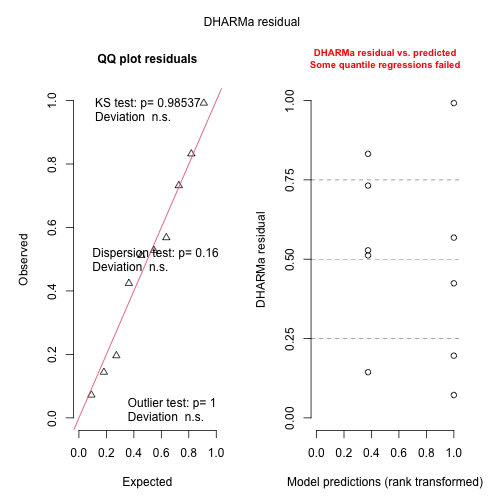

```r
# Testing model residuals
simulationOutput <- simulateResiduals(fittedModel = gr_te_cd_2, plot = F)
plot(simulationOutput)# No problems
```

Cadmium significantly decreases growth rate for Te. Best model is with gamma distribution.

```r
### Intraspecific competition----------
```

```r
#### Tu----------

# Testing the effect of cadmium on intraspecific competition using different distributions
intra_tu_cd_1 <- glmmTMB(Tu_intra ~ Environment,
                         data = subset(param_all_w0, Tu_Regime == "SR1" &
                                         Te_Regime == "SR4"))
intra_tu_cd_2 <- glmmTMB(
  Tu_intra + 1 ~ Environment,
  data = subset(param_all_w0, Tu_Regime == "SR1" &
                  Te_Regime == "SR4"),
  family = Gamma(link = "log")
)
intra_tu_cd_3 <- glmmTMB(
  Tu_intra + 1 ~ Environment,
  data = subset(param_all_w0, Tu_Regime == "SR1" &
                  Te_Regime == "SR4"),
  family = gaussian(link = "log")
)

AIC(intra_tu_cd_1, intra_tu_cd_2, intra_tu_cd_3)
```

```
##               df       AIC
## intra_tu_cd_1  3 -40.56181
## intra_tu_cd_2  3 -41.11643
## intra_tu_cd_3  3 -40.56181
```

```r
#No difference between the models. In this case we should use the simplest model, which will be the gaussian distribution

summary(intra_tu_cd_1)
```

```
##  Family: gaussian  ( identity )
## Formula:
## Tu_intra ~ Environment
## Data:
## subset(param_all_w0, Tu_Regime == "SR1" & Te_Regime == "SR4")
##
##       AIC       BIC    logLik
##     -40.6     -39.7      23.3
## -2*log(L)  df.resid
##     -46.6         7
##
##
## Dispersion estimate for gaussian family (sigma^2): 0.000556
##
## Conditional model:
##              Estimate Std. Error
## (Intercept)  0.007612   0.010549
## EnvironmentN 0.052126   0.014918
##              z value Pr(>|z|)
## (Intercept)    0.722 0.470524
## EnvironmentN   3.494 0.000476 ***
## ---
## Signif. codes:
##   0 '***' 0.001 '**' 0.01 '*'
##   0.05 '.' 0.1 ' ' 1
```

```
##
##  DHARMa: qgam was unable to calculate quantile regression for quantile 0.25. Possibly to few (unique) data points / predictions. The quantile will be ommited in plots and significance calculations.
```

```
##
##  DHARMa: qgam was unable to calculate quantile regression for quantile 0.5. Possibly to few (unique) data points / predictions. The quantile will be ommited in plots and significance calculations.
```

```
##
##  DHARMa: qgam was unable to calculate quantile regression for quantile 0.75. Possibly to few (unique) data points / predictions. The quantile will be ommited in plots and significance calculations.
```

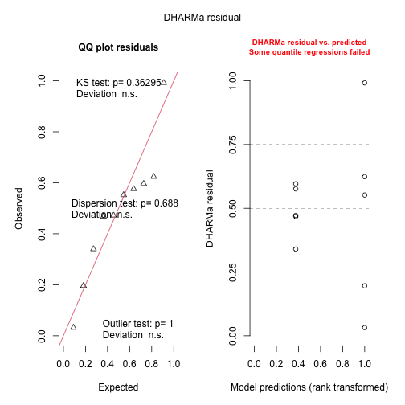

```r
# Testing model residuals
simulationOutput <- simulateResiduals(fittedModel = intra_tu_cd_1, plot = F)
plot(simulationOutput)# No problems
```

Presence of cadmium decreases intraspecific competition.

```r
#### Te----------
```

```r
# Testing the effect of cadmium on intraspecific competition using different distributions
intra_te_cd_1 <- glmmTMB(Te_intra ~ Environment,
                         data = subset(param_all_w0, Tu_Regime == "SR1" &
                                         Te_Regime == "SR4"))
intra_te_cd_2 <- glmmTMB(
  Te_intra + 1 ~ Environment,
  data = subset(param_all_w0, Tu_Regime == "SR1" &
                  Te_Regime == "SR4"),
  family = Gamma(link = "log")
)
intra_te_cd_3 <- glmmTMB(
  Te_intra + 1 ~ Environment,
  data = subset(param_all_w0, Tu_Regime == "SR1" &
                  Te_Regime == "SR4"),
  family = gaussian(link = "log")
)

AIC(intra_te_cd_1, intra_te_cd_2, intra_te_cd_3)
```

```
##               df       AIC
## intra_te_cd_1  3 -23.38694
## intra_te_cd_2  3 -23.07006
## intra_te_cd_3  3 -23.38694
```

```r
#No difference between the models. In this case we should use the simplest model, which will be the gaussian distribution

summary(intra_te_cd_1) #Again very similar estimates
```

```
##  Family: gaussian  ( identity )
## Formula:
## Te_intra ~ Environment
## Data:
## subset(param_all_w0, Tu_Regime == "SR1" & Te_Regime == "SR4")
##
##       AIC       BIC    logLik
##     -23.4     -22.5      14.7
## -2*log(L)  df.resid
##     -29.4         7
##
##
## Dispersion estimate for gaussian family (sigma^2): 0.0031
##
## Conditional model:
##              Estimate Std. Error
## (Intercept)   0.01964    0.02490
## EnvironmentN  0.02650    0.03521
##              z value Pr(>|z|)
## (Intercept)    0.789    0.430
## EnvironmentN   0.753    0.452
```

```
##
##  DHARMa: qgam was unable to calculate quantile regression for quantile 0.25. Possibly to few (unique) data points / predictions. The quantile will be ommited in plots and significance calculations.
```

```
##
##  DHARMa: qgam was unable to calculate quantile regression for quantile 0.5. Possibly to few (unique) data points / predictions. The quantile will be ommited in plots and significance calculations.
```

```
##
##  DHARMa: qgam was unable to calculate quantile regression for quantile 0.75. Possibly to few (unique) data points / predictions. The quantile will be ommited in plots and significance calculations.
```

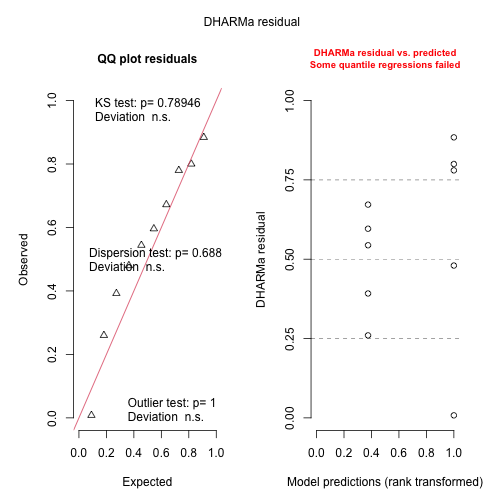

```r
# Testing the model residuals
simulationOutput <- simulateResiduals(fittedModel = intra_te_cd_1, plot = F)
plot(simulationOutput) #No problems
```

```r
### Interspecific competition----------
```

```r
#### Tu----------
```

```r
# Testing the effect of cadmium on interspecific competition using different distributions. Here we only use the data from the regimes that evolved in the no-cadmium environment
inter_tu_cd_1 <- glmmTMB(Tu_inter ~ Environment, data = subset(param_all_w0, (Tu_Regime ==
                                                                                "SR1" & Te_Regime == "SR4")))
inter_tu_cd_2 <- glmmTMB(
  Tu_inter + 1 ~ Environment,
  data = subset(param_all_w0, (Tu_Regime == "SR1" &
                                 Te_Regime == "SR4")),
  family = Gamma(link = "log")
)
inter_tu_cd_3 <- glmmTMB(
  Tu_inter + 1 ~ Environment,
  data = subset(param_all_w0, (Tu_Regime == "SR1" &
                                 Te_Regime == "SR4")),
  family = gaussian(link = "log")
)

AIC(inter_tu_cd_1, inter_tu_cd_2, inter_tu_cd_3)
```

```
##               df       AIC
## inter_tu_cd_1  3 -44.94957
## inter_tu_cd_2  3 -45.08177
## inter_tu_cd_3  3 -44.94957
```

```r
# Same as above, similar AIC so we use the simplest model

summary(inter_tu_cd_1)
```

```
##  Family: gaussian  ( identity )
## Formula:
## Tu_inter ~ Environment
## Data:
## subset(param_all_w0, (Tu_Regime == "SR1" & Te_Regime == "SR4"))
##
##       AIC       BIC    logLik
##     -44.9     -44.0      25.5
## -2*log(L)  df.resid
##     -50.9         7
##
##
## Dispersion estimate for gaussian family (sigma^2): 0.000359
##
## Conditional model:
##              Estimate Std. Error
## (Intercept)  0.012704   0.008471
## EnvironmentN 0.061119   0.011979
##              z value Pr(>|z|)
## (Intercept)    1.500    0.134
## EnvironmentN   5.102 3.36e-07 ***
## ---
## Signif. codes:
##   0 '***' 0.001 '**' 0.01 '*'
##   0.05 '.' 0.1 ' ' 1
```

```
##
##  DHARMa: qgam was unable to calculate quantile regression for quantile 0.25. Possibly to few (unique) data points / predictions. The quantile will be ommited in plots and significance calculations.
```

```
##
##  DHARMa: qgam was unable to calculate quantile regression for quantile 0.5. Possibly to few (unique) data points / predictions. The quantile will be ommited in plots and significance calculations.
```

```
##
##  DHARMa: qgam was unable to calculate quantile regression for quantile 0.75. Possibly to few (unique) data points / predictions. The quantile will be ommited in plots and significance calculations.
```

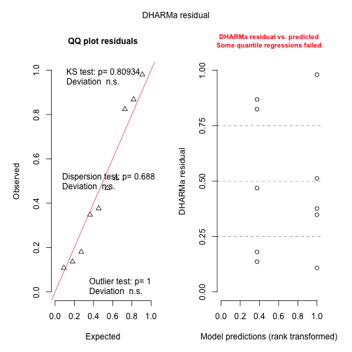

```r
# Testing model residuals
simulationOutput <- simulateResiduals(fittedModel = inter_tu_cd_1, plot = F)
plot(simulationOutput) #no problems
```

```r
#### Te----------
```

```r
# Testing the effect of cadmium on interspecific competition using different distributions. Here we only use the data from the regimes that evolved in the no-cadmium environment
inter_te_cd_1 <- glmmTMB(Te_inter ~ Environment, data = subset(param_all_w0, (Tu_Regime ==
                                                                                "SR1" & Te_Regime == "SR4")))
inter_te_cd_2 <- glmmTMB(
  Te_inter + 1 ~ Environment,
  data = subset(param_all_w0, (Tu_Regime == "SR1" &
                                 Te_Regime == "SR4")),
  family = Gamma(link = "log")
)
inter_te_cd_3 <- glmmTMB(
  Te_inter + 1 ~ Environment,
  data = subset(param_all_w0, (Tu_Regime == "SR1" &
                                 Te_Regime == "SR4")),
  family = gaussian(link = "log")
)

#testing which is the best model
AIC(inter_te_cd_1, inter_te_cd_2, inter_te_cd_3)
```

```
##               df       AIC
## inter_te_cd_1  3 -30.57466
## inter_te_cd_2  3 -30.35679
## inter_te_cd_3  3 -30.57466
```

```r
# Same as above, similar AIC so we use the simplest model

summary(inter_te_cd_1)
```

```
##  Family: gaussian  ( identity )
## Formula:
## Te_inter ~ Environment
## Data:
## subset(param_all_w0, (Tu_Regime == "SR1" & Te_Regime == "SR4"))
##
##       AIC       BIC    logLik
##     -30.6     -29.7      18.3
## -2*log(L)  df.resid
##     -36.6         7
##
##
## Dispersion estimate for gaussian family (sigma^2): 0.00151
##
## Conditional model:
##              Estimate Std. Error
## (Intercept)  0.003388   0.017381
## EnvironmentN 0.123266   0.024580
##              z value Pr(>|z|)
## (Intercept)    0.195    0.845
## EnvironmentN   5.015 5.31e-07 ***
## ---
## Signif. codes:
##   0 '***' 0.001 '**' 0.01 '*'
##   0.05 '.' 0.1 ' ' 1
```

```
##
##  DHARMa: qgam was unable to calculate quantile regression for quantile 0.25. Possibly to few (unique) data points / predictions. The quantile will be ommited in plots and significance calculations.
```

```
##
##  DHARMa: qgam was unable to calculate quantile regression for quantile 0.5. Possibly to few (unique) data points / predictions. The quantile will be ommited in plots and significance calculations.
```

```
##
##  DHARMa: qgam was unable to calculate quantile regression for quantile 0.75. Possibly to few (unique) data points / predictions. The quantile will be ommited in plots and significance calculations.
```

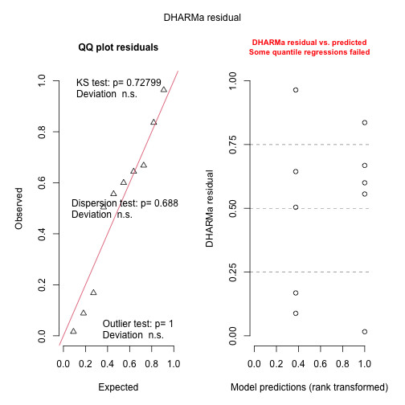

```r
# Testing residuals
simulationOutput <- simulateResiduals(fittedModel = inter_te_cd_1, plot = F)
plot(simulationOutput) #No problems
```

Presence of cadmium decreases interspecific competition for Te

```r
## Summary----------
```

Results are cited in Table S5. The estimate, z-value and p-value correspond to the row indicated by EnvironmentN, which correspond to the differences between the no cadmium and cadmium environment.

```r
summary(gr_tu_cd_2)
```

```
##  Family: Gamma  ( log )
## Formula:
## Tu_lambda ~ Environment
## Data:
## subset(param_all_w0, Tu_Regime == "SR1" & Te_Regime == "SR4")
##
##       AIC       BIC    logLik
##       7.6       8.5      -0.8
## -2*log(L)  df.resid
##       1.6         7
##
##
## Dispersion estimate for Gamma family (sigma^2): 0.0183
##
## Conditional model:
##              Estimate Std. Error
## (Intercept)   0.20483    0.06051
## EnvironmentN  0.92454    0.08557
##              z value Pr(>|z|)
## (Intercept)    3.385 0.000712 ***
## EnvironmentN  10.804  < 2e-16 ***
## ---
## Signif. codes:
##   0 '***' 0.001 '**' 0.01 '*'
##   0.05 '.' 0.1 ' ' 1
```

```r
summary(gr_te_cd_2)
```

```
##  Family: Gamma  ( log )
## Formula:
## Te_lambda ~ Environment
## Data:
## subset(param_all_w0, Tu_Regime == "SR1" & Te_Regime == "SR4")
##
##       AIC       BIC    logLik
##      38.4      39.3     -16.2
## -2*log(L)  df.resid
##      32.4         7
##
##
## Dispersion estimate for Gamma family (sigma^2): 0.108
##
## Conditional model:
##              Estimate Std. Error
## (Intercept)    0.6725     0.1472
## EnvironmentN   1.3521     0.2081
##              z value Pr(>|z|)
## (Intercept)    4.570 4.88e-06 ***
## EnvironmentN   6.497 8.21e-11 ***
## ---
## Signif. codes:
##   0 '***' 0.001 '**' 0.01 '*'
##   0.05 '.' 0.1 ' ' 1
```

```r
summary(intra_tu_cd_1)
```

```
##  Family: gaussian  ( identity )
## Formula:
## Tu_intra ~ Environment
## Data:
## subset(param_all_w0, Tu_Regime == "SR1" & Te_Regime == "SR4")
##
##       AIC       BIC    logLik
##     -40.6     -39.7      23.3
## -2*log(L)  df.resid
##     -46.6         7
##
##
## Dispersion estimate for gaussian family (sigma^2): 0.000556
##
## Conditional model:
##              Estimate Std. Error
## (Intercept)  0.007612   0.010549
## EnvironmentN 0.052126   0.014918
##              z value Pr(>|z|)
## (Intercept)    0.722 0.470524
## EnvironmentN   3.494 0.000476 ***
## ---
## Signif. codes:
##   0 '***' 0.001 '**' 0.01 '*'
##   0.05 '.' 0.1 ' ' 1
```

```r
summary(intra_te_cd_1)
```

```
##  Family: gaussian  ( identity )
## Formula:
## Te_intra ~ Environment
## Data:
## subset(param_all_w0, Tu_Regime == "SR1" & Te_Regime == "SR4")
##
##       AIC       BIC    logLik
##     -23.4     -22.5      14.7
## -2*log(L)  df.resid
##     -29.4         7
##
##
## Dispersion estimate for gaussian family (sigma^2): 0.0031
##
## Conditional model:
##              Estimate Std. Error
## (Intercept)   0.01964    0.02490
## EnvironmentN  0.02650    0.03521
##              z value Pr(>|z|)
## (Intercept)    0.789    0.430
## EnvironmentN   0.753    0.452
```

```r
summary(inter_tu_cd_1)
```

```
##  Family: gaussian  ( identity )
## Formula:
## Tu_inter ~ Environment
## Data:
## subset(param_all_w0, (Tu_Regime == "SR1" & Te_Regime == "SR4"))
##
##       AIC       BIC    logLik
##     -44.9     -44.0      25.5
## -2*log(L)  df.resid
##     -50.9         7
##
##
## Dispersion estimate for gaussian family (sigma^2): 0.000359
##
## Conditional model:
##              Estimate Std. Error
## (Intercept)  0.012704   0.008471
## EnvironmentN 0.061119   0.011979
##              z value Pr(>|z|)
## (Intercept)    1.500    0.134
## EnvironmentN   5.102 3.36e-07 ***
## ---
## Signif. codes:
##   0 '***' 0.001 '**' 0.01 '*'
##   0.05 '.' 0.1 ' ' 1
```

```r
summary(inter_te_cd_1)
```

```
##  Family: gaussian  ( identity )
## Formula:
## Te_inter ~ Environment
## Data:
## subset(param_all_w0, (Tu_Regime == "SR1" & Te_Regime == "SR4"))
##
##       AIC       BIC    logLik
##     -30.6     -29.7      18.3
## -2*log(L)  df.resid
##     -36.6         7
##
##
## Dispersion estimate for gaussian family (sigma^2): 0.00151
##
## Conditional model:
##              Estimate Std. Error
## (Intercept)  0.003388   0.017381
## EnvironmentN 0.123266   0.024580
##              z value Pr(>|z|)
## (Intercept)    0.195    0.845
## EnvironmentN   5.015 5.31e-07 ***
## ---
## Signif. codes:
##   0 '***' 0.001 '**' 0.01 '*'
##   0.05 '.' 0.1 ' ' 1
```

```r
Anova(gr_tu_cd_2)
```

```
## Analysis of Deviance Table (Type II Wald chisquare tests)
##
## Response: Tu_lambda
##              Chisq Df Pr(>Chisq)
## Environment 116.73  1  < 2.2e-16
##
## Environment ***
## ---
## Signif. codes:
##   0 '***' 0.001 '**' 0.01 '*'
##   0.05 '.' 0.1 ' ' 1
```

```r
Anova(gr_te_cd_2)
```

```
## Analysis of Deviance Table (Type II Wald chisquare tests)
##
## Response: Te_lambda
##              Chisq Df Pr(>Chisq)
## Environment 42.207  1   8.21e-11
##
## Environment ***
## ---
## Signif. codes:
##   0 '***' 0.001 '**' 0.01 '*'
##   0.05 '.' 0.1 ' ' 1
```

```r
Anova(intra_tu_cd_1)
```

```
## Analysis of Deviance Table (Type II Wald chisquare tests)
##
## Response: Tu_intra
##              Chisq Df Pr(>Chisq)
## Environment 12.209  1  0.0004756
##
## Environment ***
## ---
## Signif. codes:
##   0 '***' 0.001 '**' 0.01 '*'
##   0.05 '.' 0.1 ' ' 1
```

```r
Anova(intra_te_cd_1)
```

```
## Analysis of Deviance Table (Type II Wald chisquare tests)
##
## Response: Te_intra
##              Chisq Df Pr(>Chisq)
## Environment 0.5666  1     0.4516
```

```r
Anova(inter_tu_cd_1)
```

```
## Analysis of Deviance Table (Type II Wald chisquare tests)
##
## Response: Tu_inter
##             Chisq Df Pr(>Chisq)
## Environment 26.03  1  3.361e-07 ***
## ---
## Signif. codes:
##   0 '***' 0.001 '**' 0.01 '*'
##   0.05 '.' 0.1 ' ' 1
```

```r
Anova(inter_te_cd_1)
```

```
## Analysis of Deviance Table (Type II Wald chisquare tests)
##
## Response: Te_inter
##              Chisq Df Pr(>Chisq)
## Environment 25.149  1  5.308e-07
##
## Environment ***
## ---
## Signif. codes:
##   0 '***' 0.001 '**' 0.01 '*'
##   0.05 '.' 0.1 ' ' 1
```

```r
## Does evolution change the performance in cadmium?----------
```

```r
### Growth rate----------
```

```r
#### Tu----------

# Testing the effect of evolution on cadmium on growth rate on cadmium watered plants using different distributions
gr_tu_ev_1 <- glmmTMB(Tu_lambda ~ Tu_Regime,
                      data = subset(param_all_w0, Environment == "Cd" &
                                      Te_Regime == "SR4"))
gr_tu_ev_2 <- glmmTMB(
  Tu_lambda ~ Tu_Regime,
  data = subset(param_all_w0, Environment == "Cd" &
                  Te_Regime == "SR4"),
  family = Gamma(link = "log")
)
gr_tu_ev_3 <- glmmTMB(
  Tu_lambda ~ Tu_Regime,
  data = subset(param_all_w0, Environment == "Cd" &
                  Te_Regime == "SR4"),
  family = gaussian(link = "log")
)

AIC(gr_tu_ev_1, gr_tu_ev_2, gr_tu_ev_3)
```

```
##            df       AIC
## gr_tu_ev_1  3 -6.250300
## gr_tu_ev_2  3 -6.597109
## gr_tu_ev_3  3 -6.250300
```

```r
# There are no differences between AIC. In this case we will use the gamma, because that was the best distribution for the other tests. The results are very similar between normal and gamma distributions

summary(gr_tu_ev_2)
```

```
##  Family: Gamma  ( log )
## Formula:
## Tu_lambda ~ Tu_Regime
## Data:
## subset(param_all_w0, Environment == "Cd" & Te_Regime == "SR4")
##
##       AIC       BIC    logLik
##      -6.6      -6.0       6.3
## -2*log(L)  df.resid
##     -12.6         6
##
##
## Dispersion estimate for Gamma family (sigma^2): 0.00843
##
## Conditional model:
##              Estimate Std. Error
## (Intercept)   0.20483    0.04106
## Tu_RegimeSR2  0.15103    0.06160
##              z value Pr(>|z|)
## (Intercept)    4.988  6.1e-07 ***
## Tu_RegimeSR2   2.452   0.0142 *
## ---
## Signif. codes:
##   0 '***' 0.001 '**' 0.01 '*'
##   0.05 '.' 0.1 ' ' 1
```

```
##
##  DHARMa: qgam was unable to calculate quantile regression for quantile 0.25. Possibly to few (unique) data points / predictions. The quantile will be ommited in plots and significance calculations.
```

```
##
##  DHARMa: qgam was unable to calculate quantile regression for quantile 0.5. Possibly to few (unique) data points / predictions. The quantile will be ommited in plots and significance calculations.
```

```
##
##  DHARMa: qgam was unable to calculate quantile regression for quantile 0.75. Possibly to few (unique) data points / predictions. The quantile will be ommited in plots and significance calculations.
```

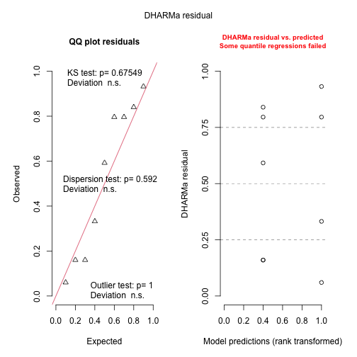

```r
# Testing the residuals
simulationOutput <- simulateResiduals(fittedModel = gr_tu_ev_2, plot = F)
plot(simulationOutput) #no problems
```

No differences between models. Evolution in cadmium increases the growth rate in cadmium for Tu

```r
#### Te----------
```

```r
# Testing the effect of evolution on cadmium on growth rate on cadmium watered plants using different distributions
gr_te_ev_1 <- glmmTMB(Te_lambda ~ Te_Regime,
                      data = subset(param_all_w0, Environment == "Cd" & Tu_Regime == "SR1"))
gr_te_ev_2 <- glmmTMB(
  Te_lambda ~ Te_Regime,
  data = subset(param_all_w0, Environment == "Cd" &
                  Tu_Regime == "SR1"),
  family = Gamma(link = "log")
)
gr_te_ev_3 <- glmmTMB(
  Te_lambda ~ Te_Regime,
  data = subset(param_all_w0, Environment == "Cd" &
                  Tu_Regime == "SR1"),
  family = gaussian(link = "log")
)

AIC(gr_te_ev_1, gr_te_ev_2, gr_te_ev_3)
```

```
##            df      AIC
## gr_te_ev_1  3 15.09473
## gr_te_ev_2  3 15.67314
## gr_te_ev_3  3 15.09473
```

```r
# There are no differences between AIC. In this case we will use the gamma, because that was the best distribution for the other tests. The results are very similar between normal and gamma distributions

summary(gr_te_ev_2)
```

```
##  Family: Gamma  ( log )
## Formula:
## Te_lambda ~ Te_Regime
## Data:
## subset(param_all_w0, Environment == "Cd" & Tu_Regime == "SR1")
##
##       AIC       BIC    logLik
##      15.7      16.6      -4.8
## -2*log(L)  df.resid
##       9.7         7
##
##
## Dispersion estimate for Gamma family (sigma^2): 0.0338
##
## Conditional model:
##              Estimate Std. Error
## (Intercept)   0.67254    0.08222
## Te_RegimeSR5  0.19442    0.11627
##              z value Pr(>|z|)
## (Intercept)    8.180 2.84e-16 ***
## Te_RegimeSR5   1.672   0.0945 .
## ---
## Signif. codes:
##   0 '***' 0.001 '**' 0.01 '*'
##   0.05 '.' 0.1 ' ' 1
```

```
##
##  DHARMa: qgam was unable to calculate quantile regression for quantile 0.25. Possibly to few (unique) data points / predictions. The quantile will be ommited in plots and significance calculations.
```

```
##
##  DHARMa: qgam was unable to calculate quantile regression for quantile 0.5. Possibly to few (unique) data points / predictions. The quantile will be ommited in plots and significance calculations.
```

```
##
##  DHARMa: qgam was unable to calculate quantile regression for quantile 0.75. Possibly to few (unique) data points / predictions. The quantile will be ommited in plots and significance calculations.
```

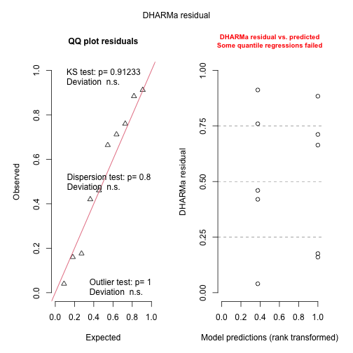

```r
# Testing residuals
simulationOutput <- simulateResiduals(fittedModel = gr_te_ev_2, plot = F)
plot(simulationOutput)# No problems
```

No difference between models Evolution in cadmium increases growth rate in cadmium, but only marginally

```r
### Intraspecif competition----------
```

```r
#### Tu----------
```

```r
# Testing the effect of evolution on cadmium on intraspecific competition on cadmium watered plants using different distributions
intra_tu_ev_1 <- glmmTMB(Tu_intra ~ Tu_Regime,
                         data = subset(param_all_w0, Environment == "Cd" & Te_Regime == "SR4"))
intra_tu_ev_2 <- glmmTMB(
  Tu_intra + 1 ~ Tu_Regime,
  data = subset(param_all_w0, Environment == "Cd" &
                  Te_Regime == "SR4"),
  family = Gamma(link = "log")
)
intra_tu_ev_3 <- glmmTMB(
  Tu_intra + 1 ~ Tu_Regime,
  data = subset(param_all_w0, Environment == "Cd" &
                  Te_Regime == "SR4"),
  family = gaussian(link = "log")
)

AIC(intra_tu_ev_1, intra_tu_ev_2, intra_tu_ev_3)
```

```
##               df       AIC
## intra_tu_ev_1  3 -50.63671
## intra_tu_ev_2  3 -50.74333
## intra_tu_ev_3  3 -50.63671
```

```r
# No differences between AICs, so the best model is the simplest (normal)

summary(intra_tu_ev_1)
```

```
##  Family: gaussian  ( identity )
## Formula:
## Tu_intra ~ Tu_Regime
## Data:
## subset(param_all_w0, Environment == "Cd" & Te_Regime == "SR4")
##
##       AIC       BIC    logLik
##     -50.6     -50.0      28.3
## -2*log(L)  df.resid
##     -56.6         6
##
##
## Dispersion estimate for gaussian family (sigma^2): 0.000108
##
## Conditional model:
##              Estimate Std. Error
## (Intercept)  0.007612   0.004653
## Tu_RegimeSR2 0.004910   0.006980
##              z value Pr(>|z|)
## (Intercept)    1.636    0.102
## Tu_RegimeSR2   0.703    0.482
```

```
##
##  DHARMa: qgam was unable to calculate quantile regression for quantile 0.25. Possibly to few (unique) data points / predictions. The quantile will be ommited in plots and significance calculations.
```

```
##
##  DHARMa: qgam was unable to calculate quantile regression for quantile 0.5. Possibly to few (unique) data points / predictions. The quantile will be ommited in plots and significance calculations.
```

```
##
##  DHARMa: qgam was unable to calculate quantile regression for quantile 0.75. Possibly to few (unique) data points / predictions. The quantile will be ommited in plots and significance calculations.
```

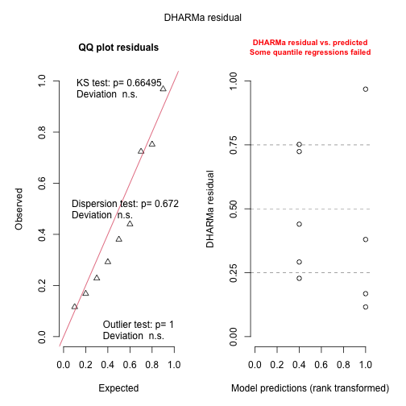

```r
# Testing the residuals
simulationOutput <- simulateResiduals(fittedModel = intra_tu_ev_1, plot = F)
plot(simulationOutput) #no problems
```

Similar models. Evolution in cadmium does not affect intraspecific competition in Tu

```r
#### Te----------

# Testing the effect of evolution on cadmium on intraspecific competition on cadmium watered plants using different distributions
intra_te_ev_1 <- glmmTMB(Te_intra ~ Te_Regime,
                         data = subset(param_all_w0, Environment == "Cd" & Tu_Regime == "SR1"))
intra_te_ev_2 <- glmmTMB(
  Te_intra + 1 ~ Te_Regime,
  data = subset(param_all_w0, Environment == "Cd" &
                  Tu_Regime == "SR1"),
  family = Gamma(link = "log")
)
intra_te_ev_3 <- glmmTMB(
  Te_intra + 1 ~ Te_Regime,
  data = subset(param_all_w0, Environment == "Cd" &
                  Tu_Regime == "SR1"),
  family = gaussian(link = "log")
)

AIC(intra_te_ev_1, intra_te_ev_2, intra_te_ev_3)
```

```
##               df       AIC
## intra_te_ev_1  3 -45.63305
## intra_te_ev_2  3 -45.49541
## intra_te_ev_3  3 -45.63305
```

```r
# No differences between AICs, so the best model is the simplest (normal)

summary(intra_te_ev_1)
```

```
##  Family: gaussian  ( identity )
## Formula:
## Te_intra ~ Te_Regime
## Data:
## subset(param_all_w0, Environment == "Cd" & Tu_Regime == "SR1")
##
##       AIC       BIC    logLik
##     -45.6     -44.7      25.8
## -2*log(L)  df.resid
##     -51.6         7
##
##
## Dispersion estimate for gaussian family (sigma^2): 0.000335
##
## Conditional model:
##              Estimate Std. Error
## (Intercept)  0.019636   0.008186
## Te_RegimeSR5 0.025775   0.011577
##              z value Pr(>|z|)
## (Intercept)    2.399   0.0165 *
## Te_RegimeSR5   2.226   0.0260 *
## ---
## Signif. codes:
##   0 '***' 0.001 '**' 0.01 '*'
##   0.05 '.' 0.1 ' ' 1
```

```
##
##  DHARMa: qgam was unable to calculate quantile regression for quantile 0.25. Possibly to few (unique) data points / predictions. The quantile will be ommited in plots and significance calculations.
```

```
##
##  DHARMa: qgam was unable to calculate quantile regression for quantile 0.5. Possibly to few (unique) data points / predictions. The quantile will be ommited in plots and significance calculations.
```

```
##
##  DHARMa: qgam was unable to calculate quantile regression for quantile 0.75. Possibly to few (unique) data points / predictions. The quantile will be ommited in plots and significance calculations.
```

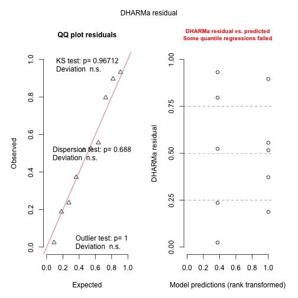

```r
# Testing residuals
simulationOutput <- simulateResiduals(fittedModel = intra_te_ev_1, plot = F)
plot(simulationOutput) #no problems
```

Evolution in cadmium increases intraspecific competition for Te

```r
### Interspecific competition----------
```

```r
#### Tu----------
```

```r
# Testing the effect of evolution on cadmium on interspecific competition on cadmium watered plants using different distributions
inter_tu_ev_1 <- glmmTMB(Tu_inter ~ Tu_Regime * Te_Regime,
                         data = subset(param_all_w0, Environment == "Cd"))
inter_tu_ev_2 <- glmmTMB(
  Tu_inter + 1 ~ Tu_Regime * Te_Regime,
  data = subset(param_all_w0, Environment == "Cd"),
  family = Gamma(link = "log")
)
inter_tu_ev_3 <- glmmTMB(
  Tu_inter + 1 ~ Tu_Regime * Te_Regime,
  data = subset(param_all_w0, Environment == "Cd"),
  family = gaussian(link = "log")
)

AIC(inter_tu_ev_1, inter_tu_ev_2, inter_tu_ev_3)
```

```
##               df       AIC
## inter_tu_ev_1  5 -84.36195
## inter_tu_ev_2  5 -84.23251
## inter_tu_ev_3  5 -84.36195
```

```r
# No differences between AICs, so the best model is the simplest (normal)

summary(inter_tu_ev_1)
```

```
##  Family: gaussian  ( identity )
## Formula:
## Tu_inter ~ Tu_Regime * Te_Regime
## Data:
## subset(param_all_w0, Environment == "Cd")
##
##       AIC       BIC    logLik
##     -84.4     -79.9      47.2
## -2*log(L)  df.resid
##     -94.4        13
##
##
## Dispersion estimate for gaussian family (sigma^2): 0.00031
##
## Conditional model:
##                            Estimate
## (Intercept)                0.012704
## Tu_RegimeSR2               0.005336
## Te_RegimeSR5              -0.011925
## Tu_RegimeSR2:Te_RegimeSR5  0.005180
##                           Std. Error
## (Intercept)                 0.007869
## Tu_RegimeSR2                0.011804
## Te_RegimeSR5                0.011128
## Tu_RegimeSR2:Te_RegimeSR5   0.016693
##                           z value
## (Intercept)                 1.614
## Tu_RegimeSR2                0.452
## Te_RegimeSR5               -1.072
## Tu_RegimeSR2:Te_RegimeSR5   0.310
##                           Pr(>|z|)
## (Intercept)                  0.106
## Tu_RegimeSR2                 0.651
## Te_RegimeSR5                 0.284
## Tu_RegimeSR2:Te_RegimeSR5    0.756
```

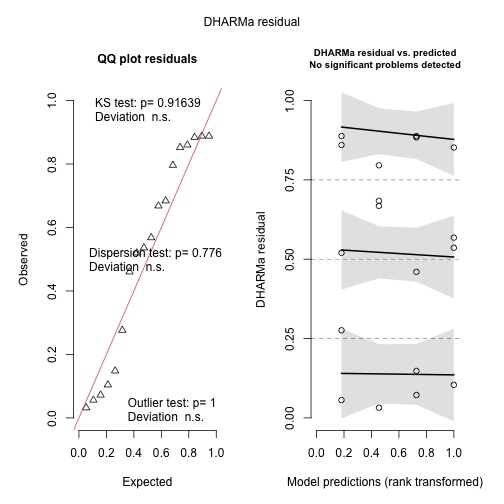

```r
# Testing residuals
simulationOutput <- simulateResiduals(fittedModel = inter_tu_ev_1, plot = F)
plot(simulationOutput) #no problem
```

There is no difference between AIC for the models

```r
#### Te----------
```

```r
# Testing the effect of evolution on cadmium on interspecific competition on cadmium watered plants using different distributions
inter_te_ev_1 <- glmmTMB(Te_inter ~ Te_Regime * Tu_Regime,
                         data = subset(param_all_w0, Environment == "Cd"))
inter_te_ev_2 <- glmmTMB(
  Te_inter + 1 ~ Te_Regime * Tu_Regime,
  data = subset(param_all_w0, Environment == "Cd"),
  family = Gamma(link = "log")
)
inter_te_ev_3 <- glmmTMB(
  Te_inter + 1 ~ Te_Regime * Tu_Regime,
  data = subset(param_all_w0, Environment == "Cd"),
  family = gaussian(link = "log")
)

AIC(inter_te_ev_1, inter_te_ev_2, inter_te_ev_3)
```

```
##               df       AIC
## inter_te_ev_1  5 -69.00638
## inter_te_ev_2  5 -68.71846
## inter_te_ev_3  5 -69.00638
```

```r
# No differences between models so we will use the simpler one

summary(inter_te_ev_1)
```

```
##  Family: gaussian  ( identity )
## Formula:
## Te_inter ~ Te_Regime * Tu_Regime
## Data:
## subset(param_all_w0, Environment == "Cd")
##
##       AIC       BIC    logLik
##     -69.0     -64.6      39.5
## -2*log(L)  df.resid
##     -79.0        13
##
##
## Dispersion estimate for gaussian family (sigma^2): 0.000727
##
## Conditional model:
##                            Estimate
## (Intercept)                0.003388
## Te_RegimeSR5               0.052926
## Tu_RegimeSR2               0.017589
## Te_RegimeSR5:Tu_RegimeSR2 -0.058106
##                           Std. Error
## (Intercept)                 0.012055
## Te_RegimeSR5                0.017048
## Tu_RegimeSR2                0.018082
## Te_RegimeSR5:Tu_RegimeSR2   0.025572
##                           z value
## (Intercept)                 0.281
## Te_RegimeSR5                3.104
## Tu_RegimeSR2                0.973
## Te_RegimeSR5:Tu_RegimeSR2  -2.272
##                           Pr(>|z|)
## (Intercept)                0.77870
## Te_RegimeSR5               0.00191
## Tu_RegimeSR2               0.33071
## Te_RegimeSR5:Tu_RegimeSR2  0.02307
##
## (Intercept)
## Te_RegimeSR5              **
## Tu_RegimeSR2
## Te_RegimeSR5:Tu_RegimeSR2 *
## ---
## Signif. codes:
##   0 '***' 0.001 '**' 0.01 '*'
##   0.05 '.' 0.1 ' ' 1
```

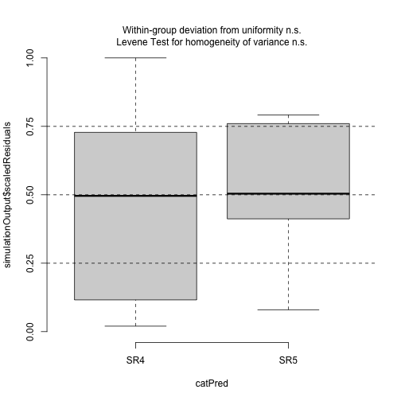

```r
# Testing residuals
simulationOutput <- simulateResiduals(fittedModel = inter_te_ev_1, plot = F, )

plotResiduals(simulationOutput,
              subset(param_all_w0, Environment == "Cd")$Te_Regime)
```

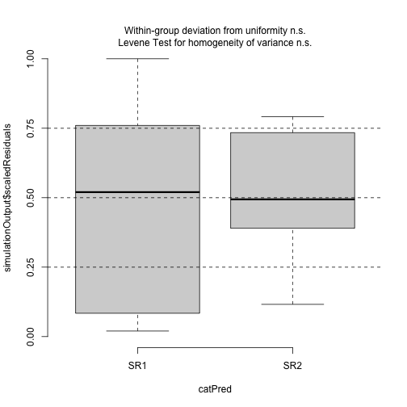

```r
plotResiduals(simulationOutput,
              subset(param_all_w0, Environment == "Cd")$Tu_Regime)
```

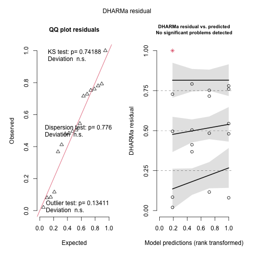

```r
plot(simulationOutput) #no problem
```

```r
# emmeans to check which comparisons are significant
emmeans(inter_te_ev_1, pairwise ~ Te_Regime + Tu_Regime, type = "response")
```

```
## $emmeans
##  Te_Regime Tu_Regime  emmean     SE
##  SR4       SR1       0.00339 0.0121
##  SR5       SR1       0.05631 0.0121
##  SR4       SR2       0.02098 0.0135
##  SR5       SR2       0.01580 0.0135
##  df lower.CL upper.CL
##  13 -0.02266   0.0294
##  13  0.03027   0.0824
##  13 -0.00814   0.0501
##  13 -0.01332   0.0449
##
## Confidence level used: 0.95
##
## $contrasts
##  contrast          estimate     SE
##  SR4 SR1 - SR5 SR1 -0.05293 0.0170
##  SR4 SR1 - SR4 SR2 -0.01759 0.0181
##  SR4 SR1 - SR5 SR2 -0.01241 0.0181
##  SR5 SR1 - SR4 SR2  0.03534 0.0181
##  SR5 SR1 - SR5 SR2  0.04052 0.0181
##  SR4 SR2 - SR5 SR2  0.00518 0.0191
##  df t.ratio p.value
##  13  -3.104  0.0369
##  13  -0.973  0.7670
##  13  -0.686  0.9005
##  13   1.954  0.2541
##  13   2.241  0.1635
##  13   0.272  0.9926
##
## P value adjustment: tukey method for comparing a family of 4 estimates
```

No difference between AIC

Evolution in cadmium affects interspecific competition of Te and this effect depends on the evolution of Tu. Namely against Tu that did not evolve in cadmium the populations of Te that evolved in cadmium suffer more from interspecific competition. However, this does not happen for Tu that evolved in cadmium, where competition slightly decreases when Te evolved in cadmium.

```r
## Summary----------
```

Results of the ANOVA for growth rate and intraspecific competition are cited in text. The ANOVA results for interspecific competition are cited in Table S3A. The results from emmeans for Te are cited in Table S3B.

```r
summary(gr_tu_ev_2)
```

```
##  Family: Gamma  ( log )
## Formula:
## Tu_lambda ~ Tu_Regime
## Data:
## subset(param_all_w0, Environment == "Cd" & Te_Regime == "SR4")
##
##       AIC       BIC    logLik
##      -6.6      -6.0       6.3
## -2*log(L)  df.resid
##     -12.6         6
##
##
## Dispersion estimate for Gamma family (sigma^2): 0.00843
##
## Conditional model:
##              Estimate Std. Error
## (Intercept)   0.20483    0.04106
## Tu_RegimeSR2  0.15103    0.06160
##              z value Pr(>|z|)
## (Intercept)    4.988  6.1e-07 ***
## Tu_RegimeSR2   2.452   0.0142 *
## ---
## Signif. codes:
##   0 '***' 0.001 '**' 0.01 '*'
##   0.05 '.' 0.1 ' ' 1
```

```r
summary(gr_te_ev_2)
```

```
##  Family: Gamma  ( log )
## Formula:
## Te_lambda ~ Te_Regime
## Data:
## subset(param_all_w0, Environment == "Cd" & Tu_Regime == "SR1")
##
##       AIC       BIC    logLik
##      15.7      16.6      -4.8
## -2*log(L)  df.resid
##       9.7         7
##
##
## Dispersion estimate for Gamma family (sigma^2): 0.0338
##
## Conditional model:
##              Estimate Std. Error
## (Intercept)   0.67254    0.08222
## Te_RegimeSR5  0.19442    0.11627
##              z value Pr(>|z|)
## (Intercept)    8.180 2.84e-16 ***
## Te_RegimeSR5   1.672   0.0945 .
## ---
## Signif. codes:
##   0 '***' 0.001 '**' 0.01 '*'
##   0.05 '.' 0.1 ' ' 1
```

```r
## intra

summary(intra_tu_ev_1)
```

```
##  Family: gaussian  ( identity )
## Formula:
## Tu_intra ~ Tu_Regime
## Data:
## subset(param_all_w0, Environment == "Cd" & Te_Regime == "SR4")
##
##       AIC       BIC    logLik
##     -50.6     -50.0      28.3
## -2*log(L)  df.resid
##     -56.6         6
##
##
## Dispersion estimate for gaussian family (sigma^2): 0.000108
##
## Conditional model:
##              Estimate Std. Error
## (Intercept)  0.007612   0.004653
## Tu_RegimeSR2 0.004910   0.006980
##              z value Pr(>|z|)
## (Intercept)    1.636    0.102
## Tu_RegimeSR2   0.703    0.482
```

```r
summary(intra_te_ev_1)
```

```
##  Family: gaussian  ( identity )
## Formula:
## Te_intra ~ Te_Regime
## Data:
## subset(param_all_w0, Environment == "Cd" & Tu_Regime == "SR1")
##
##       AIC       BIC    logLik
##     -45.6     -44.7      25.8
## -2*log(L)  df.resid
##     -51.6         7
##
##
## Dispersion estimate for gaussian family (sigma^2): 0.000335
##
## Conditional model:
##              Estimate Std. Error
## (Intercept)  0.019636   0.008186
## Te_RegimeSR5 0.025775   0.011577
##              z value Pr(>|z|)
## (Intercept)    2.399   0.0165 *
## Te_RegimeSR5   2.226   0.0260 *
## ---
## Signif. codes:
##   0 '***' 0.001 '**' 0.01 '*'
##   0.05 '.' 0.1 ' ' 1
```

```r
## inter
summary(inter_tu_ev_1)
```

```
##  Family: gaussian  ( identity )
## Formula:
## Tu_inter ~ Tu_Regime * Te_Regime
## Data:
## subset(param_all_w0, Environment == "Cd")
##
##       AIC       BIC    logLik
##     -84.4     -79.9      47.2
## -2*log(L)  df.resid
##     -94.4        13
##
##
## Dispersion estimate for gaussian family (sigma^2): 0.00031
##
## Conditional model:
##                            Estimate
## (Intercept)                0.012704
## Tu_RegimeSR2               0.005336
## Te_RegimeSR5              -0.011925
## Tu_RegimeSR2:Te_RegimeSR5  0.005180
##                           Std. Error
## (Intercept)                 0.007869
## Tu_RegimeSR2                0.011804
## Te_RegimeSR5                0.011128
## Tu_RegimeSR2:Te_RegimeSR5   0.016693
##                           z value
## (Intercept)                 1.614
## Tu_RegimeSR2                0.452
## Te_RegimeSR5               -1.072
## Tu_RegimeSR2:Te_RegimeSR5   0.310
##                           Pr(>|z|)
## (Intercept)                  0.106
## Tu_RegimeSR2                 0.651
## Te_RegimeSR5                 0.284
## Tu_RegimeSR2:Te_RegimeSR5    0.756
```

```r
summary(inter_te_ev_1)
```

```
##  Family: gaussian  ( identity )
## Formula:
## Te_inter ~ Te_Regime * Tu_Regime
## Data:
## subset(param_all_w0, Environment == "Cd")
##
##       AIC       BIC    logLik
##     -69.0     -64.6      39.5
## -2*log(L)  df.resid
##     -79.0        13
##
##
## Dispersion estimate for gaussian family (sigma^2): 0.000727
##
## Conditional model:
##                            Estimate
## (Intercept)                0.003388
## Te_RegimeSR5               0.052926
## Tu_RegimeSR2               0.017589
## Te_RegimeSR5:Tu_RegimeSR2 -0.058106
##                           Std. Error
## (Intercept)                 0.012055
## Te_RegimeSR5                0.017048
## Tu_RegimeSR2                0.018082
## Te_RegimeSR5:Tu_RegimeSR2   0.025572
##                           z value
## (Intercept)                 0.281
## Te_RegimeSR5                3.104
## Tu_RegimeSR2                0.973
## Te_RegimeSR5:Tu_RegimeSR2  -2.272
##                           Pr(>|z|)
## (Intercept)                0.77870
## Te_RegimeSR5               0.00191
## Tu_RegimeSR2               0.33071
## Te_RegimeSR5:Tu_RegimeSR2  0.02307
##
## (Intercept)
## Te_RegimeSR5              **
## Tu_RegimeSR2
## Te_RegimeSR5:Tu_RegimeSR2 *
## ---
## Signif. codes:
##   0 '***' 0.001 '**' 0.01 '*'
##   0.05 '.' 0.1 ' ' 1
```

```r
# Anova

Anova(gr_tu_ev_2)
```

```
## Analysis of Deviance Table (Type II Wald chisquare tests)
##
## Response: Tu_lambda
##           Chisq Df Pr(>Chisq)
## Tu_Regime 6.012  1    0.01421 *
## ---
## Signif. codes:
##   0 '***' 0.001 '**' 0.01 '*'
##   0.05 '.' 0.1 ' ' 1
```

```r
Anova(gr_te_ev_2)
```

```
## Analysis of Deviance Table (Type II Wald chisquare tests)
##
## Response: Te_lambda
##            Chisq Df Pr(>Chisq)
## Te_Regime 2.7959  1     0.0945 .
## ---
## Signif. codes:
##   0 '***' 0.001 '**' 0.01 '*'
##   0.05 '.' 0.1 ' ' 1
```

```r
## intra

Anova(intra_tu_ev_1)
```

```
## Analysis of Deviance Table (Type II Wald chisquare tests)
##
## Response: Tu_intra
##            Chisq Df Pr(>Chisq)
## Tu_Regime 0.4947  1     0.4818
```

```r
Anova(intra_te_ev_1)
```

```
## Analysis of Deviance Table (Type II Wald chisquare tests)
##
## Response: Te_intra
##            Chisq Df Pr(>Chisq)
## Te_Regime 4.9568  1    0.02599 *
## ---
## Signif. codes:
##   0 '***' 0.001 '**' 0.01 '*'
##   0.05 '.' 0.1 ' ' 1
```

```r
## Inter
Anova(inter_tu_ev_1, type = 3)
```

```
## Analysis of Deviance Table (Type III Wald chisquare tests)
##
## Response: Tu_inter
##                      Chisq Df
## (Intercept)         2.6064  1
## Tu_Regime           0.2043  1
## Te_Regime           1.1483  1
## Tu_Regime:Te_Regime 0.0963  1
##                     Pr(>Chisq)
## (Intercept)             0.1064
## Tu_Regime               0.6512
## Te_Regime               0.2839
## Tu_Regime:Te_Regime     0.7563
```

```r
Anova(inter_te_ev_1, type = 3)
```

```
## Analysis of Deviance Table (Type III Wald chisquare tests)
##
## Response: Te_inter
##                      Chisq Df
## (Intercept)         0.0790  1
## Te_Regime           9.6376  1
## Tu_Regime           0.9461  1
## Te_Regime:Tu_Regime 5.1630  1
##                     Pr(>Chisq)
## (Intercept)           0.778700
## Te_Regime             0.001906 **
## Tu_Regime             0.330708
## Te_Regime:Tu_Regime   0.023073 *
## ---
## Signif. codes:
##   0 '***' 0.001 '**' 0.01 '*'
##   0.05 '.' 0.1 ' ' 1
```

```r
# emmeans to check which comparisons are significant
emmeans(inter_te_ev_1, pairwise ~ Te_Regime + Tu_Regime, type = "response")
```

```
## $emmeans
##  Te_Regime Tu_Regime  emmean     SE
##  SR4       SR1       0.00339 0.0121
##  SR5       SR1       0.05631 0.0121
##  SR4       SR2       0.02098 0.0135
##  SR5       SR2       0.01580 0.0135
##  df lower.CL upper.CL
##  13 -0.02266   0.0294
##  13  0.03027   0.0824
##  13 -0.00814   0.0501
##  13 -0.01332   0.0449
##
## Confidence level used: 0.95
##
## $contrasts
##  contrast          estimate     SE
##  SR4 SR1 - SR5 SR1 -0.05293 0.0170
##  SR4 SR1 - SR4 SR2 -0.01759 0.0181
##  SR4 SR1 - SR5 SR2 -0.01241 0.0181
##  SR5 SR1 - SR4 SR2  0.03534 0.0181
##  SR5 SR1 - SR5 SR2  0.04052 0.0181
##  SR4 SR2 - SR5 SR2  0.00518 0.0191
##  df t.ratio p.value
##  13  -3.104  0.0369
##  13  -0.973  0.7670
##  13  -0.686  0.9005
##  13   1.954  0.2541
##  13   2.241  0.1635
##  13   0.272  0.9926
##
## P value adjustment: tukey method for comparing a family of 4 estimates
```

```r
## Does evolution change the performance in the ancestral environment?----------
```

```r
### Growth rate----------
```

```r
#### Tu----------
```

```r
# Testing the effect of evolution on cadmium on growth rate on plants without cadmium using different distributions
gr_tu_an_1 <- glmmTMB(Tu_lambda ~ Tu_Regime,
                      data = subset(param_all_w0, Environment == "N" & Te_Regime == "SR4"))
gr_tu_an_2 <- glmmTMB(
  Tu_lambda ~ Tu_Regime,
  data = subset(param_all_w0, Environment == "N" &
                  Te_Regime == "SR4"),
  family = Gamma(link = "log")
)
gr_tu_an_3 <- glmmTMB(
  Tu_lambda ~ Tu_Regime,
  data = subset(param_all_w0, Environment == "N" &
                  Te_Regime == "SR4"),
  family = gaussian(link = "log")
)

AIC(gr_tu_an_1, gr_tu_an_2, gr_tu_an_3)
```

```
##            df      AIC
## gr_tu_an_1  3 21.41821
## gr_tu_an_2  3 20.77142
## gr_tu_an_3  3 21.41821
```

```r
summary(gr_tu_an_2)
```

```
##  Family: Gamma  ( log )
## Formula:
## Tu_lambda ~ Tu_Regime
## Data:
## subset(param_all_w0, Environment == "N" & Te_Regime == "SR4")
##
##       AIC       BIC    logLik
##      20.8      21.4      -7.4
## -2*log(L)  df.resid
##      14.8         6
##
##
## Dispersion estimate for Gamma family (sigma^2): 0.035
##
## Conditional model:
##              Estimate Std. Error
## (Intercept)   1.12937    0.08364
## Tu_RegimeSR2 -0.08860    0.12546
##              z value Pr(>|z|)
## (Intercept)   13.503   <2e-16 ***
## Tu_RegimeSR2  -0.706     0.48
## ---
## Signif. codes:
##   0 '***' 0.001 '**' 0.01 '*'
##   0.05 '.' 0.1 ' ' 1
```

```
##
##  DHARMa: qgam was unable to calculate quantile regression for quantile 0.25. Possibly to few (unique) data points / predictions. The quantile will be ommited in plots and significance calculations.
```

```
##
##  DHARMa: qgam was unable to calculate quantile regression for quantile 0.5. Possibly to few (unique) data points / predictions. The quantile will be ommited in plots and significance calculations.
```

```
##
##  DHARMa: qgam was unable to calculate quantile regression for quantile 0.75. Possibly to few (unique) data points / predictions. The quantile will be ommited in plots and significance calculations.
```

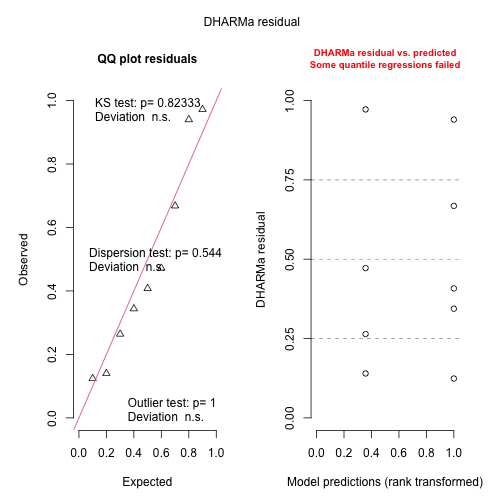

```r
# Test residuals
simulationOutput <- simulateResiduals(fittedModel = gr_tu_an_2, plot = F, )
plot(simulationOutput)# no problem
```

Gamma shows slightly lower AIC No effect, although evolution in cadmium slightly reduces growth rate.

#### Te–––––

```r
# Testing the effect of evolution on cadmium on growth rate on plants without cadmium using different distributions
gr_te_an_1 <- glmmTMB(Te_lambda ~ Te_Regime,
                      data = subset(param_all_w0, Environment == "N" & Tu_Regime == "SR1"))
gr_te_an_2 <- glmmTMB(
  Te_lambda ~ Te_Regime,
  data = subset(param_all_w0, Environment == "N" &
                  Tu_Regime == "SR1"),
  family = Gamma(link = "log")
)
gr_te_an_3 <- glmmTMB(
  Te_lambda ~ Te_Regime,
  data = subset(param_all_w0, Environment == "N" &
                  Tu_Regime == "SR1"),
  family = gaussian(link = "log")
)

AIC(gr_te_an_1, gr_te_an_2, gr_te_an_3)
```

```
##            df      AIC
## gr_te_an_1  3 52.32915
## gr_te_an_2  3 50.24893
## gr_te_an_3  3 52.32915
```

```r
# Best model is with the gamma distribution

summary(gr_te_an_2)
```

```
##  Family: Gamma  ( log )
## Formula:
## Te_lambda ~ Te_Regime
## Data:
## subset(param_all_w0, Environment == "N" & Tu_Regime == "SR1")
##
##       AIC       BIC    logLik
##      50.2      51.2     -22.1
## -2*log(L)  df.resid
##      44.2         7
##
##
## Dispersion estimate for Gamma family (sigma^2): 0.0914
##
## Conditional model:
##               Estimate Std. Error
## (Intercept)   2.024658   0.135205
## Te_RegimeSR5 -0.007472   0.191209
##              z value Pr(>|z|)
## (Intercept)   14.975   <2e-16 ***
## Te_RegimeSR5  -0.039    0.969
## ---
## Signif. codes:
##   0 '***' 0.001 '**' 0.01 '*'
##   0.05 '.' 0.1 ' ' 1
```

```
##
##  DHARMa: qgam was unable to calculate quantile regression for quantile 0.25. Possibly to few (unique) data points / predictions. The quantile will be ommited in plots and significance calculations.
```

```
##
##  DHARMa: qgam was unable to calculate quantile regression for quantile 0.5. Possibly to few (unique) data points / predictions. The quantile will be ommited in plots and significance calculations.
```

```
##
##  DHARMa: qgam was unable to calculate quantile regression for quantile 0.75. Possibly to few (unique) data points / predictions. The quantile will be ommited in plots and significance calculations.
```

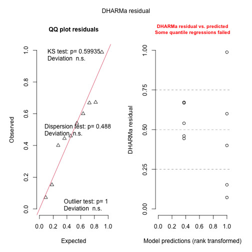

```r
simulationOutput <- simulateResiduals(fittedModel = gr_te_an_2, plot = F, )
plot(simulationOutput)
```

No effect of evolution in cadmium, although evolution in cadmium slightly reduces growth rate.

```r
### Intra----------
```

```r
#### Tu----------
```

```r
# Testing the effect of evolution on cadmium on intraspecific competition on plants without cadmium using different distributions
intra_tu_an_1 <- glmmTMB(Tu_intra ~ Tu_Regime,
                         data = subset(param_all_w0, Environment == "N" & Te_Regime == "SR4"))
intra_tu_an_2 <- glmmTMB(
  Tu_intra + 1 ~ Tu_Regime,
  data = subset(param_all_w0, Environment == "N" &
                  Te_Regime == "SR4"),
  family = Gamma(link = "log")
)
intra_tu_an_3 <- glmmTMB(
  Tu_intra + 1 ~ Tu_Regime,
  data = subset(param_all_w0, Environment == "N" &
                  Te_Regime == "SR4"),
  family = gaussian(link = "log")
)

AIC(intra_tu_an_1, intra_tu_an_2, intra_tu_an_3)
```

```
##               df       AIC
## intra_tu_an_1  3 -34.27151
## intra_tu_an_2  3 -34.45545
## intra_tu_an_3  3 -34.27151
```

```r
# No differences in AIC, best model is the simplest

summary(intra_tu_an_1)
```

```
##  Family: gaussian  ( identity )
## Formula:
## Tu_intra ~ Tu_Regime
## Data:
## subset(param_all_w0, Environment == "N" & Te_Regime == "SR4")
##
##       AIC       BIC    logLik
##     -34.3     -33.7      20.1
## -2*log(L)  df.resid
##     -40.3         6
##
##
## Dispersion estimate for gaussian family (sigma^2): 0.000667
##
## Conditional model:
##              Estimate Std. Error
## (Intercept)   0.05974    0.01155
## Tu_RegimeSR2 -0.02046    0.01733
##              z value Pr(>|z|)
## (Intercept)    5.172 2.32e-07 ***
## Tu_RegimeSR2  -1.181    0.238
## ---
## Signif. codes:
##   0 '***' 0.001 '**' 0.01 '*'
##   0.05 '.' 0.1 ' ' 1
```

```
##
##  DHARMa: qgam was unable to calculate quantile regression for quantile 0.25. Possibly to few (unique) data points / predictions. The quantile will be ommited in plots and significance calculations.
```

```
##
##  DHARMa: qgam was unable to calculate quantile regression for quantile 0.5. Possibly to few (unique) data points / predictions. The quantile will be ommited in plots and significance calculations.
```

```
##
##  DHARMa: qgam was unable to calculate quantile regression for quantile 0.75. Possibly to few (unique) data points / predictions. The quantile will be ommited in plots and significance calculations.
```

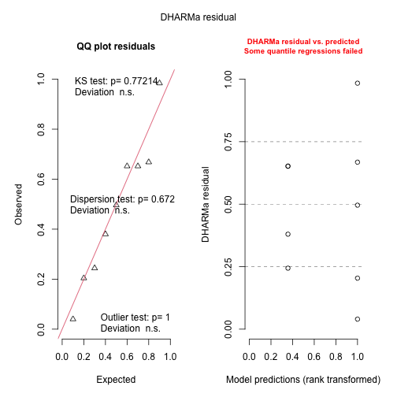

```r
# Testing the residuals
simulationOutput <- simulateResiduals(fittedModel = intra_tu_an_1, plot = F, )
plot(simulationOutput) #no problem
```

No effect of evolution in cadmium, although it slighlty decreases the intraspecific competition

```r
#### Te----------
```

```r
# Testing the effect of evolution on cadmium on intraspecific competition on plants without cadmium using different distributions
intra_te_an_1 <- glmmTMB(Te_intra ~ Te_Regime,
                         data = subset(param_all_w0, Environment == "N" & Tu_Regime == "SR1"))
intra_te_an_2 <- glmmTMB(
  Te_intra + 1 ~ Te_Regime,
  data = subset(param_all_w0, Environment == "N" &
                  Tu_Regime == "SR1"),
  family = Gamma(link = "log")
)
intra_te_an_3 <- glmmTMB(
  Te_intra + 1 ~ Te_Regime,
  data = subset(param_all_w0, Environment == "N" &
                  Tu_Regime == "SR1"),
  family = gaussian(link = "log")
)

AIC(intra_te_an_1, intra_te_an_2, intra_te_an_3)
```

```
##               df       AIC
## intra_te_an_1  3 -23.83275
## intra_te_an_2  3 -22.79972
## intra_te_an_3  3 -23.83275
```

```r
# No differences in AIC, best model is the simplest

summary(intra_te_an_1)
```

```
##  Family: gaussian  ( identity )
## Formula:
## Te_intra ~ Te_Regime
## Data:
## subset(param_all_w0, Environment == "N" & Tu_Regime == "SR1")
##
##       AIC       BIC    logLik
##     -23.8     -22.9      14.9
## -2*log(L)  df.resid
##     -29.8         7
##
##
## Dispersion estimate for gaussian family (sigma^2): 0.00296
##
## Conditional model:
##              Estimate Std. Error
## (Intercept)   0.04614    0.02435
## Te_RegimeSR5  0.05493    0.03443
##              z value Pr(>|z|)
## (Intercept)    1.895   0.0581 .
## Te_RegimeSR5   1.595   0.1107
## ---
## Signif. codes:
##   0 '***' 0.001 '**' 0.01 '*'
##   0.05 '.' 0.1 ' ' 1
```

```
##
##  DHARMa: qgam was unable to calculate quantile regression for quantile 0.25. Possibly to few (unique) data points / predictions. The quantile will be ommited in plots and significance calculations.
```

```
##
##  DHARMa: qgam was unable to calculate quantile regression for quantile 0.5. Possibly to few (unique) data points / predictions. The quantile will be ommited in plots and significance calculations.
```

```
##
##  DHARMa: qgam was unable to calculate quantile regression for quantile 0.75. Possibly to few (unique) data points / predictions. The quantile will be ommited in plots and significance calculations.
```

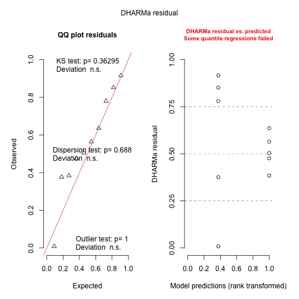

```r
# Test residuals
simulationOutput <- simulateResiduals(fittedModel = intra_te_an_1, plot = F, )
plot(simulationOutput)# no problem
```

Evolution in cadmium does not affect Te intraspecific competition in the ancestral environment

```r
### Interspecific competition----------
```

```r
#### Tu----------

# Testing the effect of evolution on cadmium on interspecific competition on plants without cadmium using different distributions
inter_tu_an_1 <- glmmTMB(Tu_inter ~ Tu_Regime * Te_Regime,
                         data = subset(param_all_w0, Environment == "N"))
inter_tu_an_2 <- glmmTMB(
  Tu_inter + 1 ~ Tu_Regime * Te_Regime,
  data = subset(param_all_w0, Environment == "N"),
  family = Gamma(link = "log")
)
inter_tu_an_3 <- glmmTMB(
  Tu_inter + 1 ~ Tu_Regime * Te_Regime,
  data = subset(param_all_w0, Environment == "N"),
  family = gaussian(link = "log")
)

AIC(inter_tu_an_1, inter_tu_an_2, inter_tu_an_3)
```

```
##               df      AIC
## inter_tu_an_1  5 -69.5475
## inter_tu_an_2  5 -69.3581
## inter_tu_an_3  5 -69.5475
```

```r
# No differences in AIC

summary(inter_tu_an_1)
```

```
##  Family: gaussian  ( identity )
## Formula:
## Tu_inter ~ Tu_Regime * Te_Regime
## Data:
## subset(param_all_w0, Environment == "N")
##
##       AIC       BIC    logLik
##     -69.5     -65.1      39.8
## -2*log(L)  df.resid
##     -79.5        13
##
##
## Dispersion estimate for gaussian family (sigma^2): 0.000705
##
## Conditional model:
##                            Estimate
## (Intercept)                0.073823
## Tu_RegimeSR2              -0.015489
## Te_RegimeSR5              -0.009909
## Tu_RegimeSR2:Te_RegimeSR5 -0.017939
##                           Std. Error
## (Intercept)                 0.011875
## Tu_RegimeSR2                0.017813
## Te_RegimeSR5                0.016794
## Tu_RegimeSR2:Te_RegimeSR5   0.025191
##                           z value
## (Intercept)                 6.217
## Tu_RegimeSR2               -0.870
## Te_RegimeSR5               -0.590
## Tu_RegimeSR2:Te_RegimeSR5  -0.712
##                           Pr(>|z|)
## (Intercept)               5.08e-10
## Tu_RegimeSR2                 0.385
## Te_RegimeSR5                 0.555
## Tu_RegimeSR2:Te_RegimeSR5    0.476
##
## (Intercept)               ***
## Tu_RegimeSR2
## Te_RegimeSR5
## Tu_RegimeSR2:Te_RegimeSR5
## ---
## Signif. codes:
##   0 '***' 0.001 '**' 0.01 '*'
##   0.05 '.' 0.1 ' ' 1
```

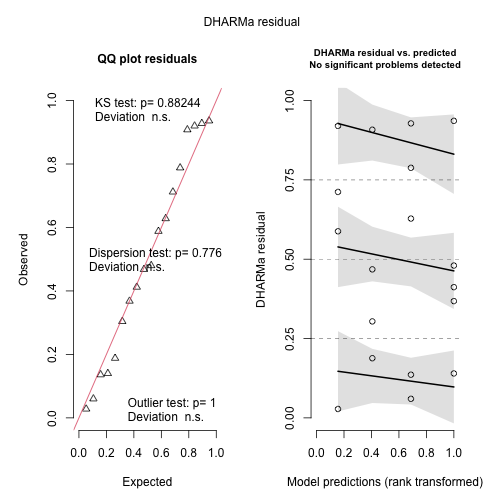

```r
# Test residuals
simulationOutput <- simulateResiduals(fittedModel = inter_tu_an_1, plot = F, )
plot(simulationOutput) # no problem
```

Evolution in cadmium does not affect sensitivity to interspecific competition for Tu in the ancestral environment

```r
#### Te----------
```

```r
# Testing the effect of evolution on cadmium on interspecific competition on plants without cadmium using different distributions
inter_te_an_1 <- glmmTMB(Te_inter ~ Te_Regime * Tu_Regime,
                         data = subset(param_all_w0, Environment == "N"))
inter_te_an_2 <- glmmTMB(
  Te_inter + 1 ~ Te_Regime * Tu_Regime,
  data = subset(param_all_w0, Environment == "N"),
  family = Gamma(link = "log")
)
inter_te_an_3 <- glmmTMB(
  Te_inter + 1 ~ Te_Regime * Tu_Regime,
  data = subset(param_all_w0, Environment == "N"),
  family = gaussian(link = "log")
)

AIC(inter_te_an_1, inter_te_an_2, inter_te_an_3)
```

```
##               df       AIC
## inter_te_an_1  5 -59.27673
## inter_te_an_2  5 -59.34098
## inter_te_an_3  5 -59.27673
```

```r
# No differences in AIC

summary(inter_te_an_1)
```

```
##  Family: gaussian  ( identity )
## Formula:
## Te_inter ~ Te_Regime * Tu_Regime
## Data:
## subset(param_all_w0, Environment == "N")
##
##       AIC       BIC    logLik
##     -59.3     -54.8      34.6
## -2*log(L)  df.resid
##     -69.3        13
##
##
## Dispersion estimate for gaussian family (sigma^2): 0.00125
##
## Conditional model:
##                            Estimate
## (Intercept)                0.126653
## Te_RegimeSR5               0.008022
## Tu_RegimeSR2              -0.024278
## Te_RegimeSR5:Tu_RegimeSR2  0.019771
##                           Std. Error
## (Intercept)                 0.015796
## Te_RegimeSR5                0.022339
## Tu_RegimeSR2                0.023694
## Te_RegimeSR5:Tu_RegimeSR2   0.033508
##                           z value
## (Intercept)                 8.018
## Te_RegimeSR5                0.359
## Tu_RegimeSR2               -1.025
## Te_RegimeSR5:Tu_RegimeSR2   0.590
##                           Pr(>|z|)
## (Intercept)               1.07e-15
## Te_RegimeSR5                 0.720
## Tu_RegimeSR2                 0.306
## Te_RegimeSR5:Tu_RegimeSR2    0.555
##
## (Intercept)               ***
## Te_RegimeSR5
## Tu_RegimeSR2
## Te_RegimeSR5:Tu_RegimeSR2
## ---
## Signif. codes:
##   0 '***' 0.001 '**' 0.01 '*'
##   0.05 '.' 0.1 ' ' 1
```

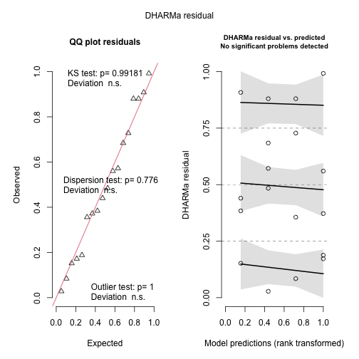

```r
# Test residuals
simulationOutput <- simulateResiduals(fittedModel = inter_te_an_1, plot = F, )
plot(simulationOutput) # no problems
```

No difference in model AIC No changes in interspecific competition for Te in the ancestral environment, after evolution in cadmium

```r
### Summary----------
```

Results of the ANOVA for growth rate and intraspecific competition are cited in text. The ANOVA results for interspecific competition are cited in Table S4.

```r
summary(gr_tu_an_2)
```

```
##  Family: Gamma  ( log )
## Formula:
## Tu_lambda ~ Tu_Regime
## Data:
## subset(param_all_w0, Environment == "N" & Te_Regime == "SR4")
##
##       AIC       BIC    logLik
##      20.8      21.4      -7.4
## -2*log(L)  df.resid
##      14.8         6
##
##
## Dispersion estimate for Gamma family (sigma^2): 0.035
##
## Conditional model:
##              Estimate Std. Error
## (Intercept)   1.12937    0.08364
## Tu_RegimeSR2 -0.08860    0.12546
##              z value Pr(>|z|)
## (Intercept)   13.503   <2e-16 ***
## Tu_RegimeSR2  -0.706     0.48
## ---
## Signif. codes:
##   0 '***' 0.001 '**' 0.01 '*'
##   0.05 '.' 0.1 ' ' 1
```

```r
summary(gr_te_an_2)
```

```
##  Family: Gamma  ( log )
## Formula:
## Te_lambda ~ Te_Regime
## Data:
## subset(param_all_w0, Environment == "N" & Tu_Regime == "SR1")
##
##       AIC       BIC    logLik
##      50.2      51.2     -22.1
## -2*log(L)  df.resid
##      44.2         7
##
##
## Dispersion estimate for Gamma family (sigma^2): 0.0914
##
## Conditional model:
##               Estimate Std. Error
## (Intercept)   2.024658   0.135205
## Te_RegimeSR5 -0.007472   0.191209
##              z value Pr(>|z|)
## (Intercept)   14.975   <2e-16 ***
## Te_RegimeSR5  -0.039    0.969
## ---
## Signif. codes:
##   0 '***' 0.001 '**' 0.01 '*'
##   0.05 '.' 0.1 ' ' 1
```

```r
summary(intra_tu_an_1)
```

```
##  Family: gaussian  ( identity )
## Formula:
## Tu_intra ~ Tu_Regime
## Data:
## subset(param_all_w0, Environment == "N" & Te_Regime == "SR4")
##
##       AIC       BIC    logLik
##     -34.3     -33.7      20.1
## -2*log(L)  df.resid
##     -40.3         6
##
##
## Dispersion estimate for gaussian family (sigma^2): 0.000667
##
## Conditional model:
##              Estimate Std. Error
## (Intercept)   0.05974    0.01155
## Tu_RegimeSR2 -0.02046    0.01733
##              z value Pr(>|z|)
## (Intercept)    5.172 2.32e-07 ***
## Tu_RegimeSR2  -1.181    0.238
## ---
## Signif. codes:
##   0 '***' 0.001 '**' 0.01 '*'
##   0.05 '.' 0.1 ' ' 1
```

```r
summary(intra_te_an_1)
```

```
##  Family: gaussian  ( identity )
## Formula:
## Te_intra ~ Te_Regime
## Data:
## subset(param_all_w0, Environment == "N" & Tu_Regime == "SR1")
##
##       AIC       BIC    logLik
##     -23.8     -22.9      14.9
## -2*log(L)  df.resid
##     -29.8         7
##
##
## Dispersion estimate for gaussian family (sigma^2): 0.00296
##
## Conditional model:
##              Estimate Std. Error
## (Intercept)   0.04614    0.02435
## Te_RegimeSR5  0.05493    0.03443
##              z value Pr(>|z|)
## (Intercept)    1.895   0.0581 .
## Te_RegimeSR5   1.595   0.1107
## ---
## Signif. codes:
##   0 '***' 0.001 '**' 0.01 '*'
##   0.05 '.' 0.1 ' ' 1
```

```r
summary(inter_tu_an_1)
```

```
##  Family: gaussian  ( identity )
## Formula:
## Tu_inter ~ Tu_Regime * Te_Regime
## Data:
## subset(param_all_w0, Environment == "N")
##
##       AIC       BIC    logLik
##     -69.5     -65.1      39.8
## -2*log(L)  df.resid
##     -79.5        13
##
##
## Dispersion estimate for gaussian family (sigma^2): 0.000705
##
## Conditional model:
##                            Estimate
## (Intercept)                0.073823
## Tu_RegimeSR2              -0.015489
## Te_RegimeSR5              -0.009909
## Tu_RegimeSR2:Te_RegimeSR5 -0.017939
##                           Std. Error
## (Intercept)                 0.011875
## Tu_RegimeSR2                0.017813
## Te_RegimeSR5                0.016794
## Tu_RegimeSR2:Te_RegimeSR5   0.025191
##                           z value
## (Intercept)                 6.217
## Tu_RegimeSR2               -0.870
## Te_RegimeSR5               -0.590
## Tu_RegimeSR2:Te_RegimeSR5  -0.712
##                           Pr(>|z|)
## (Intercept)               5.08e-10
## Tu_RegimeSR2                 0.385
## Te_RegimeSR5                 0.555
## Tu_RegimeSR2:Te_RegimeSR5    0.476
##
## (Intercept)               ***
## Tu_RegimeSR2
## Te_RegimeSR5
## Tu_RegimeSR2:Te_RegimeSR5
## ---
## Signif. codes:
##   0 '***' 0.001 '**' 0.01 '*'
##   0.05 '.' 0.1 ' ' 1
```

```r
summary(inter_te_an_1)
```

```
##  Family: gaussian  ( identity )
## Formula:
## Te_inter ~ Te_Regime * Tu_Regime
## Data:
## subset(param_all_w0, Environment == "N")
##
##       AIC       BIC    logLik
##     -59.3     -54.8      34.6
## -2*log(L)  df.resid
##     -69.3        13
##
##
## Dispersion estimate for gaussian family (sigma^2): 0.00125
##
## Conditional model:
##                            Estimate
## (Intercept)                0.126653
## Te_RegimeSR5               0.008022
## Tu_RegimeSR2              -0.024278
## Te_RegimeSR5:Tu_RegimeSR2  0.019771
##                           Std. Error
## (Intercept)                 0.015796
## Te_RegimeSR5                0.022339
## Tu_RegimeSR2                0.023694
## Te_RegimeSR5:Tu_RegimeSR2   0.033508
##                           z value
## (Intercept)                 8.018
## Te_RegimeSR5                0.359
## Tu_RegimeSR2               -1.025
## Te_RegimeSR5:Tu_RegimeSR2   0.590
##                           Pr(>|z|)
## (Intercept)               1.07e-15
## Te_RegimeSR5                 0.720
## Tu_RegimeSR2                 0.306
## Te_RegimeSR5:Tu_RegimeSR2    0.555
##
## (Intercept)               ***
## Te_RegimeSR5
## Tu_RegimeSR2
## Te_RegimeSR5:Tu_RegimeSR2
## ---
## Signif. codes:
##   0 '***' 0.001 '**' 0.01 '*'
##   0.05 '.' 0.1 ' ' 1
```

```r
Anova(gr_tu_an_2)
```

```
## Analysis of Deviance Table (Type II Wald chisquare tests)
##
## Response: Tu_lambda
##            Chisq Df Pr(>Chisq)
## Tu_Regime 0.4988  1       0.48
```

```r
Anova(gr_te_an_2)
```

```
## Analysis of Deviance Table (Type II Wald chisquare tests)
##
## Response: Te_lambda
##            Chisq Df Pr(>Chisq)
## Te_Regime 0.0015  1     0.9688
```

```r
Anova(intra_tu_an_1)
```

```
## Analysis of Deviance Table (Type II Wald chisquare tests)
##
## Response: Tu_intra
##            Chisq Df Pr(>Chisq)
## Tu_Regime 1.3944  1     0.2377
```

```r
Anova(intra_te_an_1)
```

```
## Analysis of Deviance Table (Type II Wald chisquare tests)
##
## Response: Te_intra
##            Chisq Df Pr(>Chisq)
## Te_Regime 2.5448  1     0.1107
```

```r
Anova(inter_tu_an_1, type = 3)
```

```
## Analysis of Deviance Table (Type III Wald chisquare tests)
##
## Response: Tu_inter
##                       Chisq Df
## (Intercept)         38.6465  1
## Tu_Regime            0.7561  1
## Te_Regime            0.3481  1
## Tu_Regime:Te_Regime  0.5071  1
##                     Pr(>Chisq)
## (Intercept)          5.079e-10 ***
## Tu_Regime               0.3846
## Te_Regime               0.5552
## Tu_Regime:Te_Regime     0.4764
## ---
## Signif. codes:
##   0 '***' 0.001 '**' 0.01 '*'
##   0.05 '.' 0.1 ' ' 1
```

```r
Anova(inter_te_an_1, type = 3)
```

```
## Analysis of Deviance Table (Type III Wald chisquare tests)
##
## Response: Te_inter
##                       Chisq Df
## (Intercept)         64.2908  1
## Te_Regime            0.1290  1
## Tu_Regime            1.0499  1
## Te_Regime:Tu_Regime  0.3481  1
##                     Pr(>Chisq)
## (Intercept)          1.073e-15 ***
## Te_Regime               0.7195
## Tu_Regime               0.3055
## Te_Regime:Tu_Regime     0.5552
## ---
## Signif. codes:
##   0 '***' 0.001 '**' 0.01 '*'
##   0.05 '.' 0.1 ' ' 1
```

```r
## Bootstrap analyses ----------
```

## Bootstrap differences between selection regimes

Beware this script takes a long time to run. For each question we will randomize the replicates between selection regimes, using 10000 bootstrap samples and test how many times do we recover significant differences between the different regimes just by chance.

```r
set.seed(1809) # Setting the seed to ensure reproducibility
nboot <- 10000 # Number of bootstrap samples

if (!evaluation) {
  load(file = "./Analyses/Bootstrap_stats_tests.RData")
} else{
  print("Running bootstrap")
}
```

### Does cadmium change parameters?

#### Tu

```r
if (evaluation) {
  #' # Bootstrap to reestimate the p-value obtained for growth rate and intraspecific competition.
  boot_tu_gr_intra_env <- as.data.frame(t(sapply(c(1:nboot), function(x) {
    #'  # Printing every 10 samples
    if (x %% 10 == 0) {
      print(x)
    }

    #'  # Subset data to use only the Tu and Te regimes
    auxi <- subset(param_all_w0, Tu_Regime == "SR1" &
                     Te_Regime == "SR4")
    #'  # randomize the rows
    rand_numb <- sample(c(1:dim(auxi)[1]), dim(auxi)[1], replace = TRUE)
    #' # replace the lambda, intra and inter with the randomized data
    auxi$Tu_lambda <- auxi[rand_numb, "Tu_lambda"] # randomizing the trais
    auxi$Tu_intra <- auxi[rand_numb, "Tu_intra"]
    auxi$Tu_inter <- auxi[rand_numb, "Tu_inter"]

    #' #Testing the impact of environment with the new randomized data for the three traits
    gr <- glmmTMB(Tu_lambda ~ Environment,
                  data = auxi,
                  family = Gamma(link = "log"))
    intra <- glmmTMB(Tu_intra ~ Environment, data = auxi)
    inter <- glmmTMB(Tu_inter ~ Environment, data = auxi)

    #' # Estimate mean per environment for each trait
    sum_auxi <- auxi %>% group_by(Environment) %>% summarize(
      meanGr = mean(Tu_lambda, na.rm = TRUE),
      meanIntra = mean(Tu_intra, na.rm = TRUE),
      meaninter = mean(Tu_inter, na.rm = TRUE)
    ) %>% as.data.frame()

    #' # Estimate difference between no cadmium and cadmium
    #' # N Cd
    diff <- sum_auxi[2, c(2:4)] - sum_auxi[1, (2:4)]

    #' # Store the p-value
    gr_p <- as.data.frame(Anova(gr))[1, 3]
    intra_p <- as.data.frame(Anova(intra))[1, 3]
    inter_p <- as.data.frame(Anova(inter))[1, 3]

    #' # Vector with p-value and differences
    c(gr_p, intra_p, inter_p, diff[1, 1], diff[1, 2], diff[1, 3])

  })))
}
```

```r
if (evaluation) {
  #Bootstrap to reestimate the p-value obtained for growth rate and intraspecific competition.
  boot_te_gr_intra_env <- as.data.frame(t(sapply(c(1:nboot), function(x) {
    # Printing every 10 samples
    if (x %% 10 == 0) {
      print(x)
    }
    # Subset data to use only the Tu and Te regimes that evolved in no cadmium
    auxi <- subset(param_all_w0, Tu_Regime == "SR1" &
                     Te_Regime == "SR4")
    # randomize the rows
    rand_numb <- sample(c(1:dim(auxi)[1]), dim(auxi)[1], replace = TRUE)

    # replace the lambda, intra and inter with the randomized data
    auxi$Te_lambda <- auxi[rand_numb, "Te_lambda"] # randomizing the trais
    auxi$Te_intra <- auxi[rand_numb, "Te_intra"]
    auxi$Te_inter <- auxi[rand_numb, "Te_inter"]

    #Testing the impact of environment with the new randomized data for the three traits
    gr <- glmmTMB(Te_lambda ~ Environment,
                  data = auxi,
                  family = Gamma(link = "log"))
    intra <- glmmTMB(Te_intra ~ Environment, data = auxi)
    inter <- glmmTMB(Te_inter ~ Environment, data = auxi)

    # Estimate mean per environment for each trait
    sum_auxi <- auxi %>% group_by(Environment) %>% summarize(
      meanGr = mean(Te_lambda, na.rm = TRUE),
      meanIntra = mean(Te_intra, na.rm = TRUE),
      meaninter = mean(Te_inter, na.rm = TRUE)
    ) %>% as.data.frame()

    # Estimate difference between no cadmium and cadmium
    # N Cd
    diff <- sum_auxi[2, c(2:4)] - sum_auxi[1, (2:4)]

    # Store the pvalue
    gr_p <- as.data.frame(Anova(gr))[1, 3]
    intra_p <- as.data.frame(Anova(intra))[1, 3]
    inter_p <- as.data.frame(Anova(inter))[1, 3]

    # Vector with pvalue and differences
    c(gr_p, intra_p, inter_p, diff[1, 1], diff[1, 2], diff[1, 3])

  })))

  # Adding column names to the bootstrap
  colnames(boot_tu_gr_intra_env) <- c("lambda_p",
                                      "intra_p",
                                      "inter_p",
                                      "lambda_diff",
                                      "intra_diff",
                                      "inter_diff")
  colnames(boot_te_gr_intra_env) <- c("lambda_p",
                                      "intra_p",
                                      "inter_p",
                                      "lambda_diff",
                                      "intra_diff",
                                      "inter_diff")
  str(boot_te_gr_intra_env)
}
```

#### Printing the p-value

```r
#Number of times that p-value was lower than 0.05
length(which(boot_tu_gr_intra_env$lambda_p <= 0.05)) / (nboot)
```

```
## [1] 0.1308
```

```r
length(which(boot_tu_gr_intra_env$intra_p <= 0.05)) / (nboot)
```

```
## [1] 0.1122
```

```r
length(which(boot_tu_gr_intra_env$inter_p <= 0.05)) / (nboot)
```

```
## [1] 0.1205
```

```r
length(which(boot_te_gr_intra_env$lambda_p <= 0.05)) / (nboot)
```

```
## [1] 0.1673
```

```r
length(which(boot_te_gr_intra_env$intra_p <= 0.05)) / (nboot)
```

```
## [1] 0.1124
```

```r
length(which(boot_te_gr_intra_env$inter_p <= 0.05)) / (nboot)
```

```
## [1] 0.1186
```

```r
print("Boot p-values for tests between environments")
```

```
## [1] "Boot p-values for tests between environments"
```

```r
length(which(boot_tu_gr_intra_env$lambda_p <= as.data.frame(Anova(gr_tu_cd_2))[, 3])) /
  (nboot + 1)
```

```
## [1] 0.00129987
```

```r
length(which(boot_tu_gr_intra_env$intra_p <= as.data.frame(Anova(intra_tu_cd_1))[, 3])) /
  (nboot + 1)
```

```
## [1] 0.01009899
```

```r
length(which(boot_tu_gr_intra_env$inter_p <= as.data.frame(Anova(inter_tu_cd_1))[, 3])) /
  (nboot + 1)
```

```
## [1] 0.00309969
```

```r
length(which(boot_te_gr_intra_env$lambda_p <= as.data.frame(Anova(gr_te_cd_2))[, 3])) /
  (nboot + 1)
```

```
## [1] 0.00119988
```

```r
length(which(boot_te_gr_intra_env$intra_p <= as.data.frame(Anova(intra_te_cd_1))[, 3])) /
  (nboot + 1)
```

```
## [1] 0.5271473
```

```r
length(which(boot_te_gr_intra_env$inter_p <= as.data.frame(Anova(inter_te_cd_1))[, 3])) /
  (nboot + 1)
```

```
## [1] 0.00409959
```

### Does evolution change the performance in cadmium?

#### Tu

```r
if (evaluation) {
  #Bootstrap to reestimate the p-value obtained for growth rate and intraspecific competition to test if evoution affected the performance in cadmium
  boot_tu_evolcd <- as.data.frame(t(sapply(c(1:nboot), function(x) {
    # Printing every 10 samples
    if (x %% 10 == 0) {
      print(x)
    }

    # Subset data to get both Tu regimes (that is why we select the SR4 which is a Te regime, this way we guarantee that we have the two Tu regimes).

    auxi <- subset(param_all_w0, Environment == "Cd" &
                     Te_Regime == "SR4")
    # randomize the rows (to randomize the data)
    rand_numb <- sample(c(1:dim(auxi)[1]), dim(auxi)[1], replace = TRUE)
    # replace the lambda and intra with  the randomized data
    auxi$Tu_lambda <- auxi[rand_numb, "Tu_lambda"] # randomizing the trais
    auxi$Tu_intra <- auxi[rand_numb, "Tu_intra"]

    # For interspecific competition we need both regimes for Te and Tu, ence we need to subset only for the environment
    # Here we do the same thing, reshuffle the row numbers and then replace the data
    auxi2 <- subset(param_all_w0, Environment == "Cd")
    rand_numb2 <- sample(c(1:dim(auxi2)[1]), dim(auxi2)[1], replace = TRUE)
    auxi2$Tu_inter <- auxi2[rand_numb2, "Tu_inter"]

    #Testing the impact of evolution in cadmium in the performance  in cadium with the new randomized data for the three traits
    gr <- glmmTMB(Tu_lambda ~ Tu_Regime,
                  data = auxi,
                  family = Gamma(link = "log"))
    intra <- glmmTMB(Tu_intra ~ Tu_Regime, data = auxi)
    inter <- glmmTMB(Tu_inter ~ Tu_Regime * Te_Regime, data = auxi2)

    # Estimate mean per selection regime for each trait
    sum_auxi <- auxi %>% group_by(Tu_Regime) %>% summarize(
      meanGr = mean(Tu_lambda, na.rm = TRUE),
      meanIntra = mean(Tu_intra, na.rm = TRUE)
    ) %>% as.data.frame()

    sum_auxi2 <- auxi2 %>% group_by(Tu_Regime, Te_Regime) %>% summarize(meanInter =
                                                                          mean(Tu_inter, na.rm = TRUE)) %>% as.data.frame()

    # Estimate difference between evolved and non-evolved
    diff <- sum_auxi[2, c(2:3)] - sum_auxi[1, (2:3)]
    # For inter it is more complicated because we have several pairwises
    diff2 <- sum_auxi2[1, 3] - sum_auxi2[2, 3] # Evolution of the competitor with control focal
    diff3 <- sum_auxi2[1, 3] - sum_auxi2[3, 3] # Evolution of the focal with control competitor
    diff4 <- sum_auxi2[2, 3] - sum_auxi2[4, 3] # Evolution of the focal with evolved competitor
    diff5 <- sum_auxi2[3, 3] - sum_auxi2[4, 3] # Evolution of the competitor with evolved focal

    # Store the p-value
    gr_p <- as.data.frame(Anova(gr))[1, 3]
    intra_p <- as.data.frame(Anova(intra))[1, 3]
    inter_p <- as.data.frame(Anova(inter))[1, 3]
    inter_p2 <- as.data.frame(Anova(inter))[2, 3]
    inter_p3 <- as.data.frame(Anova(inter))[3, 3]

    # Vector with p-value and differences
    c(gr_p,
      intra_p,
      inter_p,
      inter_p2,
      inter_p3,
      diff[1, 1],
      diff[1, 2],
      diff2,
      diff3,
      diff4,
      diff5)

  })))
}
```

```r
if (evaluation) {
  #Bootstrap to reestimate the p-value obtained for growth rate and intraspecific competition to test if evoution affected the performance in cadmium. For T. evansi
  boot_te_evolcd <- as.data.frame(t(sapply(c(1:nboot), function(x) {
    # Printing every 10 samples
    if (x %% 10 == 0) {
      print(x)
    }
    # Subset data to get both Te regimes (that is why we select the SR1 which is a Tu regime, this way we guarantee that we have the two Te regimes).
    auxi <- subset(param_all_w0, Environment == "Cd" &
                     Tu_Regime == "SR1")
    # randomize the rows
    rand_numb <- sample(c(1:dim(auxi)[1]), dim(auxi)[1], replace = TRUE)
    # replace the lambda and intra with  the randomized data
    auxi$Te_lambda <- auxi[rand_numb, "Te_lambda"] # randomizing the trais
    auxi$Te_intra <- auxi[rand_numb, "Te_intra"]

    # For interspecific competition we need both regimes for Te and Tu, hence we need to subset only for the environment
    # Here we do the same thing, reshuffle the row numbers and then replace the data
    auxi2 <- subset(param_all_w0, Environment == "Cd")
    # reshuffle rows
    rand_numb2 <- sample(c(1:dim(auxi2)[1]), dim(auxi2)[1], replace = TRUE)
    auxi2$Te_inter <- auxi2[rand_numb2, "Te_inter"]

    #Testing the impact of evolution in cadmium in the performance  in cadium with the new randomized data for the three traits
    gr <- glmmTMB(Te_lambda ~ Te_Regime,
                  data = auxi,
                  family = Gamma(link = "log"))
    intra <- glmmTMB(Te_intra ~ Te_Regime, data = auxi)
    inter <- glmmTMB(Te_inter ~ Tu_Regime * Te_Regime, data = auxi2)

    # Estimate mean per selection regime for each trait
    sum_auxi <- auxi %>% group_by(Te_Regime) %>% summarize(
      meanGr = mean(Te_lambda, na.rm = TRUE),
      meanIntra = mean(Te_intra, na.rm = TRUE)
    ) %>% as.data.frame()

    sum_auxi2 <- auxi2 %>% group_by(Tu_Regime, Te_Regime) %>% summarize(meanInter =
                                                                          mean(Te_inter, na.rm = TRUE)) %>% as.data.frame()

    # Estimate the difference between evolved in cadmium and evolved in no cadmium
    diff <- sum_auxi[2, c(2:3)] - sum_auxi[1, (2:3)]
    diff2 <- sum_auxi2[1, 3] - sum_auxi2[2, 3] # Evolution of the competitor with control focal
    diff3 <- sum_auxi2[1, 3] - sum_auxi2[3, 3] # Evolution of the focal with control competitor
    diff4 <- sum_auxi2[2, 3] - sum_auxi2[4, 3] # Evolution of the focal with evolved competitor
    diff5 <- sum_auxi2[3, 3] - sum_auxi2[4, 3] # Evolution of the competitor with evolved focal

    # Store the p-value
    gr_p <- as.data.frame(Anova(gr))[1, 3]
    intra_p <- as.data.frame(Anova(intra))[1, 3]
    inter_p <- as.data.frame(Anova(inter))[1, 3]
    inter_p2 <- as.data.frame(Anova(inter))[2, 3]
    inter_p3 <- as.data.frame(Anova(inter))[3, 3]
    # Vector with p-value and differences
    c(gr_p,
      intra_p,
      inter_p,
      inter_p2,
      inter_p3,
      diff[1, 1],
      diff[1, 2],
      diff2,
      diff3,
      diff4,
      diff5)

  })))

  # Add column names
  colnames(boot_tu_evolcd) <- c(
    "lambda_p",
    "intra_p",
    "inter_p_TuReg",
    "inter_p_TeReg",
    "inter_p_int",
    "lambda_diff",
    "intra_diff",
    "inter_diffEvolComp_focalControl",
    "inter_diffEvolFocal_CompControl",
    "inter_diffEvolFocal_EvolComp",
    "inter_diffEvolComp_focalEvol"
  )
  colnames(boot_te_evolcd) <- c(
    "lambda_p",
    "intra_p",
    "inter_p_TuReg",
    "inter_p_TeReg",
    "inter_p_int",
    "lambda_diff",
    "intra_diff",
    "inter_diffEvolComp_focalControl",
    "inter_diffEvolFocal_CompControl",
    "inter_diffEvolFocal_EvolComp",
    "inter_diffEvolComp_focalEvol"
  )
}
```

#### Printing the p-value

```r
#Number of times that p-value was lower than 0.05
length(which(boot_tu_evolcd$lambda_p <= 0.05)) / (nboot)
```

```
## [1] 0.1338
```

```r
length(which(boot_tu_evolcd$intra_p <= 0.05)) / (nboot)
```

```
## [1] 0.106
```

```r
length(which(boot_tu_evolcd$inter_p_TuReg <= 0.05)) / (nboot)
```

```
## [1] 0.0988
```

```r
length(which(boot_tu_evolcd$inter_p_TeReg <= 0.05)) / (nboot)
```

```
## [1] 0.1085
```

```r
length(which(boot_tu_evolcd$inter_p_int <= 0.05)) / (nboot)
```

```
## [1] 0.1067
```

```r
length(which(boot_te_evolcd$lambda_p <= 0.05)) / (nboot)
```

```
## [1] 0.1141
```

```r
length(which(boot_te_evolcd$intra_p <= 0.05)) / (nboot)
```

```
## [1] 0.1195
```

```r
length(which(boot_te_evolcd$inter_p_TuReg <= 0.05)) / (nboot)
```

```
## [1] 0.1091
```

```r
length(which(boot_te_evolcd$inter_p_TeReg <= 0.05)) / (nboot)
```

```
## [1] 0.1083
```

```r
length(which(boot_te_evolcd$inter_p_int <= 0.05)) / (nboot)
```

```
## [1] 0.1061
```

```r
print("Boot p-values for tests for evolution in cadmium")
```

```
## [1] "Boot p-values for tests for evolution in cadmium"
```

```r
length(which(boot_tu_evolcd$lambda_p <= as.data.frame(Anova(gr_tu_ev_2))[, 3])) /
  (nboot + 1)
```

```
## [1] 0.07049295
```

```r
length(which(boot_tu_evolcd$intra_p <= as.data.frame(Anova(intra_tu_ev_1))[, 3])) /
  (nboot + 1)
```

```
## [1] 0.6037396
```

```r
length(which(boot_tu_evolcd$inter_p_TuReg <= as.data.frame(Anova(inter_tu_ev_1))[1, 3])) /
  (nboot + 1)
```

```
## [1] 0.4107589
```

```r
length(which(boot_tu_evolcd$inter_p_TeReg <= as.data.frame(Anova(inter_tu_ev_1))[2, 3])) /
  (nboot + 1)
```

```
## [1] 0.320468
```

```r
length(which(boot_tu_evolcd$inter_p_int <= as.data.frame(Anova(inter_tu_ev_1))[3, 3])) /
  (nboot + 1)
```

```
## [1] 0.7879212
```

```r
length(which(boot_te_evolcd$lambda_p <= as.data.frame(Anova(gr_te_ev_2))[, 3])) /
  (nboot + 1)
```

```
## [1] 0.1626837
```

```r
length(which(boot_te_evolcd$intra_p <= as.data.frame(Anova(intra_te_ev_1))[, 3])) /
  (nboot + 1)
```

```
## [1] 0.08229177
```

```r
length(which(boot_te_evolcd$inter_p_TuReg <= as.data.frame(Anova(inter_te_ev_1))[1, 3])) /
  (nboot + 1)
```

```
## [1] 0.08359164
```

```r
length(which(boot_te_evolcd$inter_p_TeReg <= as.data.frame(Anova(inter_te_ev_1))[2, 3])) /
  (nboot + 1)
```

```
## [1] 0.4345565
```

```r
length(which(boot_te_evolcd$inter_p_int <= as.data.frame(Anova(inter_te_ev_1))[3, 3])) /
  (nboot + 1)
```

```
## [1] 0.06669333
```

### Does evolution change the ancestral?

#### Tu

```r
if (evaluation) {
  #Bootstrap to reestimate the p-value obtained for growth rate and intraspecific competition to test if evoution affected the performance in the ancestral environment
  boot_tu_evolN <- as.data.frame(t(sapply(c(1:nboot), function(x) {
    # Printing every 10 samples
    if (x %% 10 == 0) {
      print(x)
    }

    # Subset data to get both Tu regimes (that is why we select the SR4 which is a Te regime, this way we guarantee that we have the two Tu regimes).
    auxi <- subset(param_all_w0, Environment == "N" &
                     Te_Regime == "SR4")

    # randomize the rows
    rand_numb <- sample(c(1:dim(auxi)[1]), dim(auxi)[1], replace = TRUE)
    # replace the lambda, intra and inter with  the randomized data
    auxi$Tu_lambda <- auxi[rand_numb, "Tu_lambda"] # randomizing the trais
    auxi$Tu_intra <- auxi[rand_numb, "Tu_intra"]

    # Subset data to get both Tu regimes (that is why we select the SR4 which is a Te regime, this way we guarantee that we have the two Tu regimes).
    auxi2 <- subset(param_all_w0, Environment == "N")
    # randomized rows
    rand_numb2 <- sample(c(1:dim(auxi2)[1]), dim(auxi2)[1], replace = TRUE)
    auxi2$Tu_inter <- auxi2[rand_numb2, "Tu_inter"]

    #Testing the impact of evolution in cadmium in the performance  in the ancestral environment with the new randomized data for the three traits
    gr <- glmmTMB(Tu_lambda ~ Tu_Regime,
                  data = auxi,
                  family = Gamma(link = "log"))
    intra <- glmmTMB(Tu_intra ~ Tu_Regime, data = auxi)
    inter <- glmmTMB(Tu_inter ~ Tu_Regime * Te_Regime, data = auxi2)

    # Estimate mean per selection regime for each trait
    sum_auxi <- auxi %>% group_by(Tu_Regime) %>% summarize(
      meanGr = mean(Tu_lambda, na.rm = TRUE),
      meanIntra = mean(Tu_intra, na.rm = TRUE)
    ) %>% as.data.frame()

    sum_auxi2 <- auxi2 %>% group_by(Tu_Regime, Te_Regime) %>% summarize(meanInter =
                                                                          mean(Tu_inter, na.rm = TRUE)) %>% as.data.frame()

    # Estimate the difference between evolved in cadmium and evolved in no cadmium
    diff <- sum_auxi[2, c(2:3)] - sum_auxi[1, (2:3)]
    diff2 <- sum_auxi2[1, 3] - sum_auxi2[2, 3] # Evolution of the competitor with control focal
    diff3 <- sum_auxi2[1, 3] - sum_auxi2[3, 3] # Evolution of the focal with control competitor
    diff4 <- sum_auxi2[2, 3] - sum_auxi2[4, 3] # Evolution of the focal with evolved competitor
    diff5 <- sum_auxi2[3, 3] - sum_auxi2[4, 3] # Evolution of the competitor with evolved focal

    # Store the p-value
    gr_p <- as.data.frame(Anova(gr))[1, 3]
    intra_p <- as.data.frame(Anova(intra))[1, 3]
    inter_p <- as.data.frame(Anova(inter))[1, 3]
    inter_p2 <- as.data.frame(Anova(inter))[2, 3]
    inter_p3 <- as.data.frame(Anova(inter))[3, 3]

    # Vector with p-value and differences
    c(gr_p,
      intra_p,
      inter_p,
      inter_p2,
      inter_p3,
      diff[1, 1],
      diff[1, 2],
      diff2,
      diff3,
      diff4,
      diff5)

  })))
}
```

```r
if (evaluation) {
  #Bootstrap to reestimate the p-value obtained for growth rate and intraspecific competition to test if evoution affected the performance in the ancestral environment. for Te
  boot_te_evolN <- as.data.frame(t(sapply(c(1:nboot), function(x) {
    # Printing every 10 samples
    if (x %% 10 == 0) {
      print(x)
    }
    # Subset data to get both Te regimes (that is why we select the SR1 which is a Tu regime, this way we guarantee that we have the two Te regimes).
    auxi <- subset(param_all_w0, Environment == "N" &
                     Tu_Regime == "SR1")
    # randomize the rows
    rand_numb <- sample(c(1:dim(auxi)[1]), dim(auxi)[1], replace = TRUE)
    # replace the lambda, intra and inter with  the randomized data
    auxi$Te_lambda <- auxi[rand_numb, "Te_lambda"] # randomizing the trais
    auxi$Te_intra <- auxi[rand_numb, "Te_intra"]

    # print(x)

    auxi2 <- subset(param_all_w0, Environment == "N")
    rand_numb2 <- sample(c(1:dim(auxi2)[1]), dim(auxi2)[1], replace = TRUE)
    auxi2$Te_inter <- auxi2[rand_numb2, "Te_inter"]

    #Testing the impact of evolution in cadmium on the performance in the ancestral environment with the new randomized data for the three traits
    gr <- glmmTMB(Te_lambda ~ Te_Regime,
                  data = auxi,
                  family = Gamma(link = "log"))
    intra <- glmmTMB(Te_intra ~ Te_Regime, data = auxi)
    inter <- glmmTMB(Te_inter ~ Tu_Regime * Te_Regime, data = auxi2)

    # Estimate mean per selection regime for each trait
    sum_auxi <- auxi %>% group_by(Te_Regime) %>% summarize(
      meanGr = mean(Te_lambda, na.rm = TRUE),
      meanIntra = mean(Te_intra, na.rm = TRUE)
    ) %>% as.data.frame()

    sum_auxi2 <- auxi2 %>% group_by(Tu_Regime, Te_Regime) %>% summarize(meanInter =
                                                                          mean(Te_inter, na.rm = TRUE)) %>% as.data.frame()

    # Estimate the difference between evolved in cadmium and evolved in no cadmium
    diff <- sum_auxi[2, c(2:3)] - sum_auxi[1, (2:3)]
    diff2 <- sum_auxi2[1, 3] - sum_auxi2[2, 3] # Evolution of the competitor with control focal
    diff3 <- sum_auxi2[1, 3] - sum_auxi2[3, 3] # Evolution of the focal with control competitor
    diff4 <- sum_auxi2[2, 3] - sum_auxi2[4, 3] # Evolution of the focal with evolved competitor
    diff5 <- sum_auxi2[3, 3] - sum_auxi2[4, 3] # Evolution of the competitor with evolved focal

    # Store the p-value
    gr_p <- as.data.frame(Anova(gr))[1, 3]
    intra_p <- as.data.frame(Anova(intra))[1, 3]
    inter_p <- as.data.frame(Anova(inter))[1, 3]
    inter_p2 <- as.data.frame(Anova(inter))[2, 3]
    inter_p3 <- as.data.frame(Anova(inter))[3, 3]

    # Vector with p-value and differences
    c(gr_p,
      intra_p,
      inter_p,
      inter_p2,
      inter_p3,
      diff[1, 1],
      diff[1, 2],
      diff2,
      diff3,
      diff4,
      diff5)

  })))

  # adding column names
  colnames(boot_tu_evolN) <- c(
    "lambda_p",
    "intra_p",
    "inter_p_TuReg",
    "inter_p_TeReg",
    "inter_p_int",
    "lambda_diff",
    "intra_diff",
    "inter_diffEvolComp_focalControl",
    "inter_diffEvolFocal_CompControl",
    "inter_diffEvolFocal_EvolComp",
    "inter_diffEvolComp_focalEvol"
  )

  colnames(boot_te_evolN) <- c(
    "lambda_p",
    "intra_p",
    "inter_p_TuReg",
    "inter_p_TeReg",
    "inter_p_int",
    "lambda_diff",
    "intra_diff",
    "inter_diffEvolComp_focalControl",
    "inter_diffEvolFocal_CompControl",
    "inter_diffEvolFocal_EvolComp",
    "inter_diffEvolComp_focalEvol"
  )
}
```

### Printing the p-value

```r
#Number of times that p-value was lower than 0.05
length(which(boot_tu_evolN$lambda_p <= 0.05)) / (nboot)
```

```
## [1] 0.135
```

```r
length(which(boot_tu_evolN$intra_p <= 0.05)) / (nboot)
```

```
## [1] 0.1199
```

```r
length(which(boot_tu_evolN$inter_p_TuReg <= 0.05)) / (nboot)
```

```
## [1] 0.1044
```

```r
length(which(boot_tu_evolN$inter_p_TeReg <= 0.05)) / (nboot)
```

```
## [1] 0.1019
```

```r
length(which(boot_tu_evolN$inter_p_int <= 0.05)) / (nboot)
```

```
## [1] 0.1053
```

```r
length(which(boot_te_evolN$lambda_p <= 0.05)) / (nboot)
```

```
## [1] 0.1286
```

```r
length(which(boot_te_evolN$intra_p <= 0.05)) / (nboot)
```

```
## [1] 0.0811
```

```r
length(which(boot_te_evolN$inter_p_TuReg <= 0.05)) / (nboot)
```

```
## [1] 0.1078
```

```r
length(which(boot_te_evolN$inter_p_TeReg <= 0.05)) / (nboot)
```

```
## [1] 0.1073
```

```r
length(which(boot_te_evolN$inter_p_int <= 0.05)) / (nboot)
```

```
## [1] 0.1079
```

```r
print("Boot p-values for tests for evolution in cadmium")
```

```
## [1] "Boot p-values for tests for evolution in cadmium"
```

```r
length(which(boot_tu_evolN$lambda_p <= as.data.frame(Anova(gr_tu_an_2))[, 3])) /
  (nboot + 1)
```

```
## [1] 0.5454455
```

```r
length(which(boot_tu_evolN$intra_p <= as.data.frame(Anova(intra_tu_an_1))[, 3])) /
  (nboot + 1)
```

```
## [1] 0.3412659
```

```r
length(which(boot_tu_evolN$inter_p_TuReg <= as.data.frame(Anova(inter_tu_an_1))[1, 3])) /
  (nboot + 1)
```

```
## [1] 0.1078892
```

```r
length(which(boot_tu_evolN$inter_p_TeReg <= as.data.frame(Anova(inter_tu_an_1))[2, 3])) /
  (nboot + 1)
```

```
## [1] 0.2282772
```

```r
length(which(boot_tu_evolN$inter_p_int <= as.data.frame(Anova(inter_tu_an_1))[3, 3])) /
  (nboot + 1)
```

```
## [1] 0.5469453
```

```r
length(which(boot_te_evolN$lambda_p <= as.data.frame(Anova(gr_te_an_2))[, 3])) /
  (nboot + 1)
```

```
## [1] 0.9744026
```

```r
length(which(boot_te_evolN$intra_p <= as.data.frame(Anova(intra_te_an_1))[, 3])) /
  (nboot + 1)
```

```
## [1] 0.180282
```

```r
length(which(boot_te_evolN$inter_p_TuReg <= as.data.frame(Anova(inter_te_an_1))[1, 3])) /
  (nboot + 1)
```

```
## [1] 0.3849615
```

```r
length(which(boot_te_evolN$inter_p_TeReg <= as.data.frame(Anova(inter_te_an_1))[2, 3])) /
  (nboot + 1)
```

```
## [1] 0.4607539
```

```r
length(which(boot_te_evolN$inter_p_int <= as.data.frame(Anova(inter_te_an_1))[3, 3])) /
  (nboot + 1)
```

```
## [1] 0.6151385
```

#### Save the results

```r
# save the results so we can reuse it later
if (evaluation) {
  save.image(file = "./Analyses/Bootstrap_stats_tests.RData")
}
print("Structural stability")
```

```
## [1] "Structural stability"
```

```r
# Predicting coexistence using structural stability----------
```